# tvivescabaleiro_PAC3

[figure not shown]

M2.991 · Aprenentatge automàtic · PAC2

2024-1 · Màster universitari en Ciència de dades (Data science)

Estudis d'Informàtica, Multimèdia i Telecomunicació

# PAC 3: Mètodes supervisats

En aquesta pràctica veurem diferents mètodes supervisats i intentarem optimitzar diverses mètriques. Observarem com els diferents models classifiquen les observacions i amb quins obtenim un millor rendiment. Després aplicarem tot el que hem après fins ara a un nou conjunt de dades, simulant un cas pràctic real.

1. Exploració d’algorismes supervisats  
   1.1. Càrrega de dades  
   1.2. Naive-Bayes  
   1.3. Anàlisi Discriminant Lineal (LDA) i Anàlisi Discriminant Quadràtic (QDA)  
   1.4. K veïns més propers (KNN)  
   1.5. Màquines de suport vectorial (SVM)  
   1.6. Arbres de decisió
2. Implementació del cas pràctic  
   2.1. Càrrega de dades  
   2.2. Anàlisi Exploratori de Dades  
   2.3. Preprocessament de Dades  
   2.4. Modelització

Consideracions generals:

- La solució plantejada no pot utilitzar mètodes, funcions o paràmetres declarats *deprecated* en futures versions, amb l’excepció de la càrrega de dades com s’indica posteriorment.
- Aquesta PAC s’ha de realitzar de forma **estrictament individual**. Qualsevol indici de còpia serà penalitzat amb un suspens (D) per a totes les parts implicades i la possible avaluació negativa de l’assignatura de forma íntegra.
- És necessari que l’estudiant indiqui **totes les fonts** que ha utilitzat per a la realització de la PAC. Si no és així, es considerarà que l’estudiant ha comès plagi, sent penalitzat amb un suspens (D) i la possible avaluació negativa de l’assignatura de forma íntegra.

Format del lliurament:

- Alguns exercicis poden suposar diversos minuts d’execució, per la qual cosa el lliurament s’ha de fer en **format notebook** i en **format HTML**, on es vegi el codi, els resultats i els comentaris de cada exercici. Es pot exportar el notebook a HTML des del menú File $\to$ Download as $\to$ HTML.
- Hi ha un tipus de cel·la especial per albergar text. Aquest tipus de cel·la us serà molt útil per respondre les diferents preguntes teòriques plantejades al llarg de l’activitat. Per canviar el tipus de cel·la a aquest tipus, al menú: Cell $\to$ Cell Type $\to$ Markdown.

**Nom i cognoms: Toni Vives Cabaleiro**

```python
import os
import shap
import copy
import tqdm
import torch
import pickle
import kagglehub
import umap
import time

import seaborn as sns
import pandas as pd
import numpy as np
import torch.nn as nn
import matplotlib.pyplot as plt
import torch.optim as optim

from matplotlib.colors import ListedColormap

from sklearn import tree
from sklearn.svm import SVC
from sklearn.tree import DecisionTreeClassifier
from sklearn.discriminant_analysis import LinearDiscriminantAnalysis
from sklearn.discriminant_analysis import QuadraticDiscriminantAnalysis
from sklearn.neighbors import KNeighborsClassifier
from sklearn.model_selection import GridSearchCV
from sklearn.naive_bayes import GaussianNB
from sklearn.metrics import accuracy_score, confusion_matrix
from sklearn.preprocessing import StandardScaler
from sklearn.model_selection import train_test_split
from sklearn.model_selection import StratifiedKFold, train_test_split
from torcheval.metrics.functional import binary_f1_score, binary_accuracy, binary_auroc

%matplotlib inline
```

# 1. Exploració d’algorismes supervisats

## 1.1. Càrrega de dades

El conjunt de dades Fashion MNIST proporcionat per Zalando consta de 70.000 imatges amb 10 classes diferents de roba repartides uniformement. No obstant això, per a aquesta pràctica utilitzarem únicament un subconjunt de 5.000 imatges que consisteix en 1.000 imatges de 5 classes diferents.

Les imatges tenen una resolució de 28x28 píxels en escala de grisos, per la qual cosa es poden representar utilitzant un vector de 784 posicions.

El següent codi carregarà les 5.000 imatges a la variable `images` i les corresponents etiquetes (en forma numèrica) a la variable `labels`. Podem comprovar que la càrrega ha estat correcta obtenint les dimensions d’aquestes dues variables.

```python
with open("data.pickle", "rb") as f:
    data = pickle.load(f)

X = data["images"]
y = data["labels"]
n_classes = 5
labels = ["T-shirt", "Trouser", "Pullover", "Dress", "Coat"]

print("Vector Image Dimensions: {}".format(X.shape))
print("Vector Label Dimensions: {}".format(y.shape))
```

```
Vector Image Dimensions: (5000, 784)
Vector Label Dimensions: (5000,)
```

Amb el codi següent podem veure un exemple d’imatge de cadascuna de les classes. Per fer-ho, reajustem el vector de 784 dimensions que representa cada imatge en una matriu de mida 28x28 i la transposem per mostrar-la:

[figure not shown]

```python
fig, ax = plt.subplots(1, n_classes, figsize=(10,10))

idxs = [np.where(y == i)[0] for i in range(n_classes)]

for i in range(n_classes):
    k = np.random.choice(idxs[i])
    ax[i].imshow(X[k].reshape(28, 28), cmap="gray")
    ax[i].set_title("{}".format(labels[i]))

plt.show()
```

**Implementació:**

Dividiu el *dataset* en dos subconjunts, *train* (80% de les dades) i *test* (20% de les dades). Nombreu els conjunts com: X_train, X_test, y_train, y_test. Utilitzeu l’opció `random_state = 24`.

Podeu utilitzar la implementació `train_test_split` de `sklearn`.

```python
from sklearn.model_selection import train_test_split

random_state = 24
X_train,X_test, y_train, y_test = train_test_split(X,y,test_size=0.2,random_state = random_state)
```

**Solució:** A continuació mostrem les separacions

```python
print("Tamany del conjunt total: ", len(X))
print("Tamany del conjunt entrenament: ", len(X_train))
print("Tamany del conjunt test: ", len(X_test))
```

```
Tamany del conjunt total:  5000
Tamany del conjunt entrenament:  4000
Tamany del conjunt test:  1000
```

Per tal de visualitzar els resultats de cada algorisme supervisat, reduirem el dataset anterior a dues dimensions.

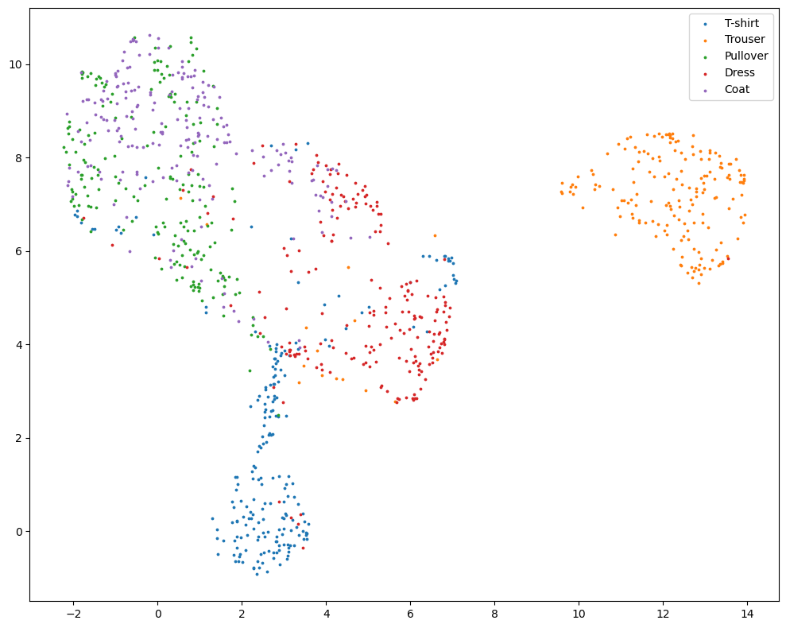

```python
model = umap.UMAP(n_components=2, random_state=42)
model.fit(X_train)
X_train_projection = model.transform(X_train)
X_test_projection = model.transform(X_test)

fig, ax = plt.subplots(1, 1, figsize=(10, 8))
for i in range(n_classes):
    ax.scatter(X_test_projection[y_test == i,0], X_test_projection[y_test == i,1], s=3, label=labels[i])
plt.legend()
plt.tight_layout()
plt.show()
```

Al llarg dels exercicis aprendrem a visualitzar gràficament les fronteres de decisió que ens retornen els diferents models. Per fer-ho, utilitzarem la funció definida a continuació, que segueix els passos següents:

1. Crear una meshgrid amb els valors mínim i màxim de 'x' i 'y'.
2. Predir el classificador amb els valors de la meshgrid.
3. Fer un reshape de les dades per obtenir el format corresponent.
4. Un cop fet això, ja podem generar el gràfic de les fronteres de decisió i afegir-hi els punts reals. Així veurem les àrees que el model considera que són d'una classe i les que considera que són d'una altra. Quan hi superposem els punts, podrem comprovar si els classifica correctament dins l'àrea que els correspon.

```python
# Create the meshgrid with the minimum and maximum values of the x and y axes
x_min, x_max = X_test_projection[:, 0].min() - 1, X_test_projection[:, 0].max() + 1
y_min, y_max = X_test_projection[:, 1].min() - 1, X_test_projection[:, 1].max() + 1

# Define the function that will visualize the decision boundary
def plot_decision_boundaries(model, X_test_projection, y_test):

    xx, yy = np.meshgrid(np.arange(x_min, x_max, 0.05),
                         np.arange(y_min, y_max, 0.05))

    # Prediction by using all values of the meshgrid
    Z = model.predict(np.c_[xx.ravel(), yy.ravel()])

    # Define the colors (one for each class)
    cmap_light = ListedColormap(['gainsboro','lightgreen','peachpuff','lightcyan', 'pink'])
    cmap_bold = ['grey','g','sandybrown','c','palevioletred']

    # Draw the borders
    Z = Z.reshape(xx.shape)
    plt.figure(figsize=(20,10))
    plt.pcolormesh(xx, yy, Z, cmap=cmap_light)

    # Draw the points
    for i in range(n_classes):
         plt.scatter(X_test_projection[y_test == i,0], X_test_projection[y_test == i,1],
                     s=3, label=labels[i], c=cmap_bold[i])
    plt.legend()
    plt.xlim(xx.min(), xx.max())
    plt.ylim(yy.min(), yy.max())
    plt.show()
```

## 1.2. Gaussian Naïve Bayes (1 punt)

El propòsit d’aquest primer exercici és comprendre el funcionament de l’algorisme Naïve-Bayes, un algorisme peculiar que es basa en el teorema de Bayes per calcular la probabilitat que una observació pertanyi a cadascuna de les classes. Aquest model assumeix que les característiques d’entrada són independents entre si, fet que permet simplificar el càlcul de les probabilitats condicionals.

**Implementació:**

1. **Entrena un Model de Naïve-Bayes:** Utilitza el conjunt de dades de *train* per entrenar un model de Naïve-Bayes. Fes servir el classificador `GaussianNB` de la biblioteca `sklearn` per a aquest objectiu.
2. **Calcula l'*Accuracy* del Model:** Un cop entrenat el model, calcula la seva precisió (*accuracy*) tant en el conjunt de *train* com en el de *test*. Això et permetrà avaluar com de bé està funcionant el teu model.
3. **Calcula la Matriu de Confusió:** Utilitza el conjunt de *test* per calcular la matriu de confusió del model. Aquesta matriu t’ajudarà a entendre millor els encerts i errors del teu classificador.
4. **Representa Gràficament la Frontera de Decisió:** Finalment, visualitza la frontera de decisió del model utilitzant el conjunt de *test*. Pots fer això amb l’ajuda de la funció `plot_decision_boundary` que ja has creat prèviament.

Per a realitzar aquests càlculs i visualitzacions, utilitza les funcions `accuracy_score` i `confusion_matrix` del paquet `metrics` de `sklearn`.

**Solució:**

```
Accuracy en el conjunt de train: 0.75
Accuracy en el conjunt de test: 0.73
Matriu de confusió (conjunt de test):
[[167   0  13  28   4]
 [  2 171   2  11   0]
 [ 11   0 156   0  27]
 [ 23   1   6 159  16]
 [  7   0 111  12  73]]
```

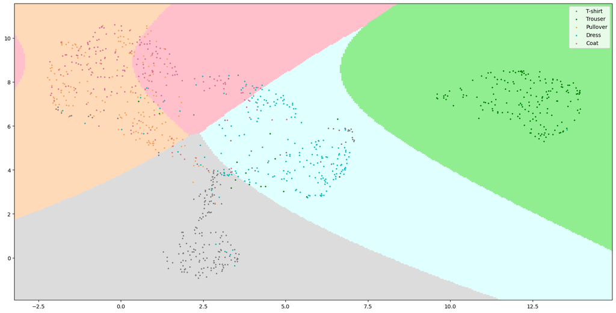

```python
from sklearn.naive_bayes import GaussianNB
from sklearn.metrics import accuracy_score, confusion_matrix

model_gnb = GaussianNB()
model_gnb.fit(X_train_projection, y_train)

# Predicció i càlcul de l'accuracy
y_train_pred = model_gnb.predict(X_train_projection)
y_test_pred = model_gnb.predict(X_test_projection)

train_accuracy = accuracy_score(y_train, y_train_pred)
test_accuracy = accuracy_score(y_test, y_test_pred)

print(f"Accuracy en el conjunt de train: {train_accuracy:.2f}")
print(f"Accuracy en el conjunt de test: {test_accuracy:.2f}")

# Matriu de confusió
conf_matrix = confusion_matrix(y_test, y_test_pred)
print("Matriu de confusió (conjunt de test):")
print(conf_matrix)

# gràfic
plot_decision_boundaries(model_gnb, X_test_projection, y_test)
```

**Anàlisi:**

Anàlisi de l'exercici.

- Com són les fronteres de decisió? Té sentit que tinguin aquesta forma amb l'algorisme utilitzat?
- Com són les prediccions obtingudes sobre el conjunt de test?

**Resposta:**

Les fronteres són suaus i no complexes, ja que l'algorisme Gaussian Naïve Bayes assumeix que les dades segueixen una distribució normal per a cada característica, i les classes es separen basant-se en probabilitats condicionals.

Aquest tipus de frontera té sentit per aquest algorisme perquè està dissenyat per treballar amb supòsits de distribució gaussiana, cosa que resulta en àrees de decisió contínues.

L'algorisme aconsegueix un bon rendiment, ja que la precisió en el conjunt de test (0.73) és força propera a la precisió en el conjunt de train(0.75).

## 1.3 Anàlisi Discriminant Lineal (LDA) i Anàlisi Discriminant Quadràtic (QDA) (1 punt)

Ara analitzaràs dos algorismes que es basen en la transformació lineal de les característiques d’entrada per maximitzar la separació entre les classes. Aquests models operen sota la suposició que les característiques segueixen una distribució gaussiana. Això et permetrà calcular les probabilitats condicionals de cada classe. Amb aquests càlculs, assignaràs a cada observació la classe que presenti la probabilitat condicional més gran.

**Implementació:**

Segueix aquests passos amb el dataset d’entrenament (*train*):

1. Entrena un model d’Anàlisi Discriminant Lineal (LDA) utilitzant el classificador `LinearDiscriminantAnalysis` de `sklearn`.
2. Calcula l’*accuracy* (precisió) del model tant en les dades de *train* com de *test*.
3. Calcula la matriu de confusió utilitzant les dades de *test*.
4. Representa gràficament la frontera de decisió amb les dades de *test*.

Aquestes accions t’ajudaran a avaluar l’eficàcia del model LDA en el teu conjunt de dades i a entendre millor com classifica les observacions.

**Solució:**

```
Train Accuracy (LDA): 0.76
Test Accuracy (LDA): 0.74
Matriu de confusió (LDA - conjunt de test):
[[164   0  14  30   4]
 [  3 171   2  10   0]
 [  9   0 135   0  50]
 [ 19   1   6 166  13]
 [  4   0  81  17 101]]
```

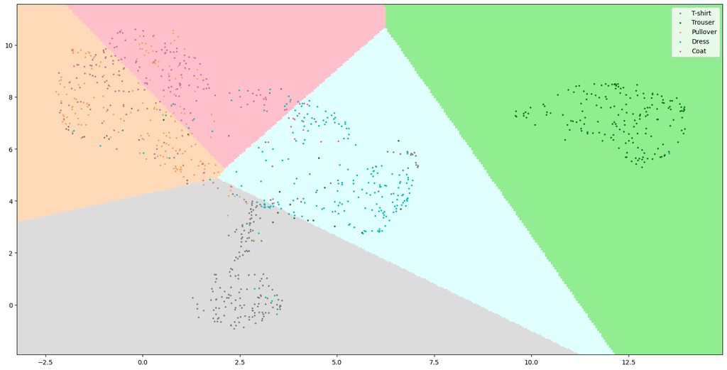

```python
from sklearn.discriminant_analysis import LinearDiscriminantAnalysis

# LDA
model_lda = LinearDiscriminantAnalysis()
model_lda.fit(X_train_projection, y_train)

# Predicció i càlcul de l’accuracy
y_train_pred_lda = model_lda.predict(X_train_projection)
y_test_pred_lda = model_lda.predict(X_test_projection)

train_accuracy_lda = accuracy_score(y_train, y_train_pred_lda)
test_accuracy_lda = accuracy_score(y_test, y_test_pred_lda)

print(f"Train Accuracy (LDA): {train_accuracy_lda:.2f}")
print(f"Test Accuracy (LDA): {test_accuracy_lda:.2f}")

# Matriu de confusió
conf_matrix_lda = confusion_matrix(y_test, y_test_pred_lda)
print("Matriu de confusió (LDA - conjunt de test):")
print(conf_matrix_lda)

# gràfic
plot_decision_boundaries(model_lda, X_test_projection, y_test)
```

**Anàlisi:**

1. Observa les fronteres de decisió que has generat. Reflexiona sobre la seva forma: s’ajusten al que esperaries de l’algorisme d’Anàlisi Discriminant Lineal (LDA)? Considera la naturalesa lineal de l’algorisme i com això influeix en la forma de les fronteres.
2. Avalua les prediccions realitzades sobre el conjunt de test. Analitza la seva precisió i com es distribueixen respecte a les fronteres de decisió. Són coherents aquestes prediccions amb el que observes a les fronteres de decisió?

Aquestes reflexions et permetran comprendre millor l’efectivitat del model LDA i la seva adequació per al conjunt de dades amb què estàs treballant.

**Resposta:**

Les fronteres de decisió generades pel LDA són clarament lineals, la qual cosa és coherent amb l’algorisme, ja que aquest assumeix que les classes són separables mitjançant hiperplans. Aquest tipus de fronteres són adequades quan les dades tenen una separabilitat lineal clara, però poden fallar si les dades mostren solapaments complexos entre classes.

La precisió del model sobre el conjunt de test és de 0.74, molt propera a la precisió sobre el conjunt de train (0.76), indicant que el model no està sobreentrenat ni infraentrenat. Això mostra que el model té un rendiment consistent amb les dades.

Les prediccions són coherents amb les fronteres generades: els punts que cauen dins de les regions corresponents a les seves classes són ben classificats, mentre que els que estan propers a les fronteres tendeixen a estar mal classificats. Això és especialment notable en les classes amb més solapament.

Tot i ser efectiu en aquest cas, el LDA pot no ser òptim per a dades amb fronteres no lineals o estructures més complexes. Es podria considerar utilitzar un model més flexible si cal millorar el rendiment.

**Implementació:**

Realitza els passos següents amb el dataset d’entrenament (*train*):

1. Entrena un model d’Anàlisi Discriminant Quadràtic (QDA) utilitzant el classificador `QuadraticDiscriminantAnalysis` de `sklearn`.
2. Calcula l’*accuracy* (precisió) del model tant en les dades de *train* com en les de *test*.
3. Calcula la matriu de confusió utilitzant les dades de *test*.
4. Representa gràficament la frontera de decisió amb les dades de *test*.

Aquests passos t’ajudaran a avaluar com el model QDA es comporta amb el teu conjunt de dades i a entendre la seva capacitat per classificar i diferenciar entre les classes.

**Solució:**

```
Train Accuracy (QDA): 0.74
Test Accuracy (QDA): 0.72
Matriu de confusió (QDA - conjunt de test):
[[166   0  14  28   4]
 [  3 171   2  10   0]
 [  8   0 139   0  47]
 [ 27   1   7 156  14]
 [  6   0  95  13  89]]
```

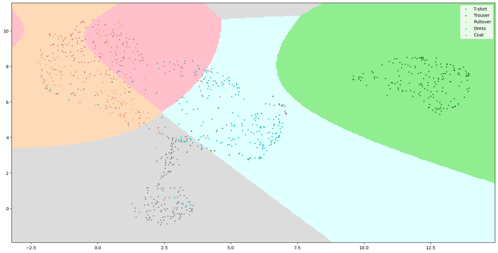

```python
from sklearn.discriminant_analysis import QuadraticDiscriminantAnalysis

#QDA
model_qda = QuadraticDiscriminantAnalysis()
model_qda.fit(X_train_projection, y_train)

# Predicció i càlcul de l'accuracy
y_train_pred_qda = model_qda.predict(X_train_projection)
y_test_pred_qda = model_qda.predict(X_test_projection)

train_accuracy_qda = accuracy_score(y_train, y_train_pred_qda)
test_accuracy_qda = accuracy_score(y_test, y_test_pred_qda)

print(f"Train Accuracy (QDA): {train_accuracy_qda:.2f}")
print(f"Test Accuracy (QDA): {test_accuracy_qda:.2f}")

# Matriu de confusió
conf_matrix_qda = confusion_matrix(y_test, y_test_pred_qda)
print("Matriu de confusió (QDA - conjunt de test):")
print(conf_matrix_qda)

# gràfic
plot_decision_boundaries(model_qda, X_test_projection, y_test)
```

**Anàlisi:**

1. Examina les fronteres de decisió que has generat. Reflexiona sobre la seva forma: és coherent amb el que esperaries de l’algorisme d’Anàlisi Discriminant Quadràtic (QDA)? Considera com la naturalesa quadràtica de l’algorisme podria influir en la forma d’aquestes fronteres.
2. Avalua les prediccions realitzades sobre el conjunt de test. Observa la seva precisió i com es distribueixen en relació amb les fronteres de decisió. Són aquestes prediccions consistents amb les fronteres observades?
3. Reflexiona sobre les diferències entre els algorismes LDA i QDA. En què es diferencien en termes de supòsits, enfocament i resultats en les teves dades?

Aquesta anàlisi et permetrà comprendre les característiques i l’eficàcia de tots dos models, LDA i QDA, i com s’apliquen al teu conjunt de dades.

**Resposta:**

Les fronteres de decisió del QDA són més flexibles i no lineals, tal com s'espera de l'algorisme. A diferència de l'LDA, que genera fronteres estrictament lineals, el QDA permet adaptar-se millor a les distribucions no lineals de les classes, com s’observa en el gràfic amb les formes corbes i més detallades de les regions.

En relació amb les diferències entre LDA i QDA:

- **Supòsits:** LDA assumeix covariàncies iguals entre classes, mentre que QDA permet covariàncies diferents, donant més flexibilitat.
- **Enfocament:** LDA cerca hiperplans lineals, mentre que QDA pot trobar fronteres més complexes adaptades a les dades.
- **Resultats:** LDA tendeix a ser més robust amb menys dades, mentre que QDA pot sobreajustar-se si les dades no són suficients o les classes estan mal definides.

En aquest cas, l’ús del QDA reflecteix millor les formes de les dades, però amb un compromís en la generalització, mostrant un rendiment similar però fronteres més adequades per dades no lineals.

## 1.4. KNN (1 punt)

En aquest punt, entendràs el funcionament de l’algorisme KNN (K-Nearest-Neighbor), que es basa en la proximitat dels punts de dades en un espai de característiques. Analitzaràs els seus avantatges i desavantatges, i comprendràs com els paràmetres que el componen influeixen en el seu comportament.

KNN és un algorisme de tipus supervisat basat en instància. Això significa:

- Supervisat: El teu conjunt de dades d’entrenament està etiquetat amb la classe o resultat esperat.
- Basat en instància (*Lazy Learning*): L’algorisme no aprèn explícitament un model, com en la Regressió Logística o els arbres de decisió. En canvi, memoritza les instàncies d’entrenament i les utilitza com a "coneixement" en la fase de predicció.

Per entendre com funciona KNN, segueix aquests passos:

1. Calcula la distància entre l’ítem a classificar i la resta d’ítems del dataset d’entrenament.
2. Selecciona els "k" elements més propers, és a dir, aquells amb la menor distància, segons el tipus de distància que utilitzis (euclidiana, cosinus, manhattan, etc).
3. Realitza una "votació de majoria" entre els k punts seleccionats: la classe que predomini en aquests punts decidirà la classificació final de l’ítem analitzat.

**Implementació:**

Realitza els passos següents amb el dataset d’entrenament (*train*):

1. Entrena un classificador KNN amb l’hiperparàmetre `n_neighbors=2` utilitzant el classificador `KNeighborsClassifier` de `sklearn`.
2. Calcula l’*accuracy* (precisió) del model tant en les dades de *train* com en les de *test*.
3. Calcula la matriu de confusió utilitzant les dades de *test*.
4. Representa gràficament la frontera de decisió amb les dades de *test*.

Si en entrenar el classificador apareix un avís (*warning*) i vols ignorar-lo, executa el codi següent abans de l’entrenament:

`import warnings`  
`warnings.filterwarnings('ignore', message='^.*will change.*$', category=FutureWarning)`

Això et permetrà avaluar l’efectivitat del model KNN amb `n_neighbors=2` en el teu conjunt de dades i entendre com es comporta en termes de classificació i separació de classes.

**Solució:**

```
Train Accuracy (KNN): 0.88
Test Accuracy (KNN): 0.73
Matriu de confusió (KNN - conjunt de test):
[[186   1   8  12   5]
 [  3 173   1   9   0]
 [  9   6 140   4  35]
 [ 26   9  19 142   9]
 [  7   3  92   9  92]]
```

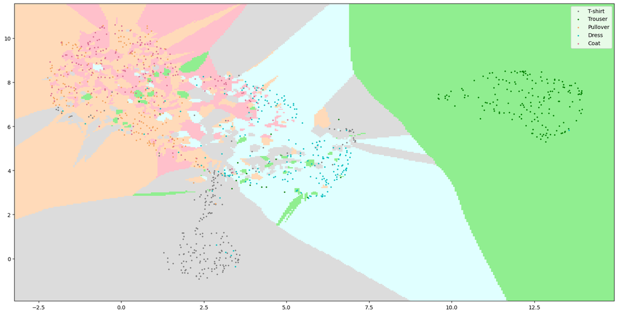

```python
from sklearn.neighbors import KNeighborsClassifier

# KNN amb n_neighbors=2
model_knn = KNeighborsClassifier(n_neighbors=2)
model_knn.fit(X_train_projection, y_train)

# Predicció i càlcul de l’accuracy
y_train_pred_knn = model_knn.predict(X_train_projection)
y_test_pred_knn = model_knn.predict(X_test_projection)

train_accuracy_knn = accuracy_score(y_train, y_train_pred_knn)
test_accuracy_knn = accuracy_score(y_test, y_test_pred_knn)

print(f"Train Accuracy (KNN): {train_accuracy_knn:.2f}")
print(f"Test Accuracy (KNN): {test_accuracy_knn:.2f}")

# Matriu de confusió
conf_matrix_knn = confusion_matrix(y_test, y_test_pred_knn)
print("Matriu de confusió (KNN - conjunt de test):")
print(conf_matrix_knn)

# gràfic
plot_decision_boundaries(model_knn, X_test_projection, y_test)
```

En el model que has entrenat, has fixat el paràmetre `n_neighbors` de manera arbitrària. Tanmateix, és possible que amb un altre valor obtinguis una millor predicció. Per trobar el valor òptim dels paràmetres d’un model (*hyperparameter tuning*), sovint s’utilitza una cerca de graella (*grid search*). Això implica entrenar un model per a cada combinació possible d’hiperparàmetres i avaluar-lo mitjançant validació creuada (*cross validation*) amb 5 particions estratificades. Posteriorment, seleccionaràs la combinació d’hiperparàmetres que hagi obtingut els millors resultats.

En aquest cas, et centraràs en optimitzar un sol hiperparàmetre:

- 𝑘: el nombre de veïns que es consideren per classificar un nou exemple. Has de provar amb tots els valors entre 1 i 20.

Realitza aquest procés per identificar el nombre òptim de veïns, fet que et permetrà millorar la precisió de les teves prediccions amb el model KNN.

**Implementació:**

Per calcular el valor òptim de l’hiperparàmetre *k* (`n_neighbors`), has de realitzar una cerca de graella amb validació creuada. Aquest procés t’ajudarà a trobar el valor òptim de *k*. Per a cada valor, calcula la seva mitjana i desviació estàndard. Després, implementa un *heatmap* per visualitzar la precisió segons els diferents valors de l’hiperparàmetre.

Utilitza el mòdul `GridSearchCV` de `sklearn` per calcular el millor hiperparàmetre. Per a la visualització del *heatmap*, fes servir la biblioteca `Seaborn`.

Aquests passos et permetran identificar de manera efectiva i visual el valor de *k* que maximitza la precisió del teu model KNN.

**Solució:**

```
Millor valor de k: 7
Millor precisió amb validació creuada: 0.81
```

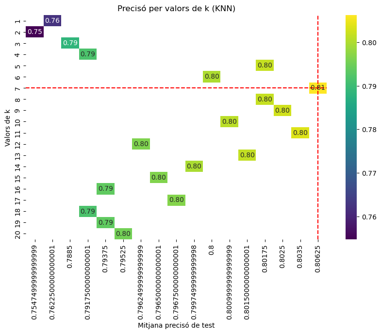

```python
from sklearn.model_selection import GridSearchCV
import seaborn as sns
import pandas as pd

# Definir l'espai d'hiperparàmetres per a la cerca
param_grid = {'n_neighbors': range(1, 21)}

model_knn = KNeighborsClassifier()
grid_search = GridSearchCV(estimator=model_knn, param_grid=param_grid, cv=5, scoring='accuracy', return_train_score=True)
grid_search.fit(X_train_projection, y_train)

results = pd.DataFrame(grid_search.cv_results_)

# Identificar el millor valor de k
best_k = grid_search.best_params_['n_neighbors']
best_score = grid_search.best_score_

print(f"Millor valor de k: {best_k}")
print(f"Millor precisió amb validació creuada: {best_score:.2f}")

#heatmap
pivot_data = results.pivot(index='param_n_neighbors', columns='mean_test_score', values='mean_test_score')

plt.figure(figsize=(10, 6))
sns.heatmap(pivot_data, annot=True, fmt=".2f", cmap='viridis', cbar=True)
plt.title("Precisó per valors de k (KNN)")
plt.xlabel("Mitjana precisó de test")
plt.ylabel("Valors de k")
plt.axvline(pivot_data.columns.get_loc(best_score) + 0.5, color='red', linestyle='--', label=f"Millor score: {best_score:.2f}")
plt.axhline(pivot_data.index.get_loc(best_k) + 0.5, color='red', linestyle='--', label=f"Millor k: {best_k}")
plt.show()
```

**Implementació:**

Segueix aquests passos amb el dataset d’entrenament (*train*):

1. Entrena un classificador KNN utilitzant el millor hiperparàmetre que hagis trobat.
2. Calcula l’*accuracy* (precisió) del model tant en les dades de *train* com en les de *test*.
3. Calcula la matriu de confusió utilitzant les dades de *test*.
4. Representa gràficament la frontera de decisió amb les dades de *test*.

Aquest procés et permetrà veure com l’hiperparàmetre òptim que has identificat millora l’eficàcia del teu model KNN en la classificació de les dades.

**Solució:**

```
Train Accuracy (Best KNN): 0.84
Test Accuracy (Best KNN): 0.79
Matriu de confusió (Best KNN - conjunt de test):
[[182   0   9  17   4]
 [  3 171   0  10   2]
 [  6   0 128   0  60]
 [ 11   1   9 168  16]
 [  1   0  50   9 143]]
```

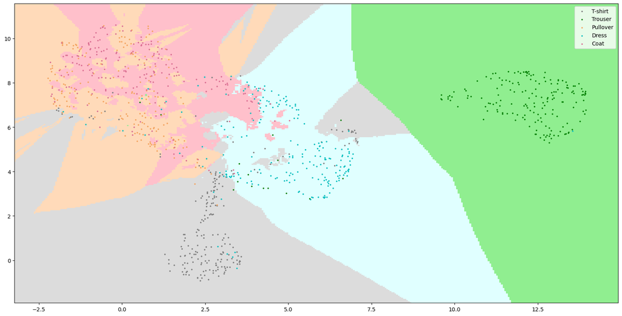

```python
# millor KNN
best_knn = KNeighborsClassifier(n_neighbors=best_k)
best_knn.fit(X_train_projection, y_train)

# Predicció i càlcul de l’accuracy
y_train_pred_best_knn = best_knn.predict(X_train_projection)
y_test_pred_best_knn = best_knn.predict(X_test_projection)

train_accuracy_best_knn = accuracy_score(y_train, y_train_pred_best_knn)
test_accuracy_best_knn = accuracy_score(y_test, y_test_pred_best_knn)

print(f"Train Accuracy (Best KNN): {train_accuracy_best_knn:.2f}")
print(f"Test Accuracy (Best KNN): {test_accuracy_best_knn:.2f}")

# Matriu de confusió
conf_matrix_best_knn = confusion_matrix(y_test, y_test_pred_best_knn)
print("Matriu de confusió (Best KNN - conjunt de test):")
print(conf_matrix_best_knn)

# gràfic
plot_decision_boundaries(best_knn, X_test_projection, y_test)
```

**Anàlisi:**

1. Comenta els resultats obtinguts en la cerca del millor hiperparàmetre. Reflexiona sobre com ha variat el rendiment del model amb els diferents valors de `n_neighbors`.
2. Analitza com es visualitza gràficament el canvi del valor de `n_neighbors`. Observes alguna tendència o patró clar? És coherent aquesta diferència entre els dos gràfics quan canvia el paràmetre?
3. Examina les fronteres de decisió que has generat. Té sentit la forma d’aquestes fronteres donat l’algorisme KNN utilitzat? Pensa en com l’elecció del nombre de veïns influeix en la forma de la frontera.
4. Avalua les prediccions realitzades sobre el conjunt de test. Observa la seva precisió i com es distribueixen en relació amb les fronteres de decisió. Són aquestes prediccions consistents amb el que observes a les fronteres de decisió?

Aquesta anàlisi t’ajudarà a comprendre l’eficàcia del model KNN amb diferents configuracions de `n_neighbors` i el seu impacte en la classificació de les dades.

**Resposta:**

Amb la cerca del millor hiperparàmetre k, s'ha determinat que el valor òptim és k=7, amb una millora en la precisió del conjunt de test (0.79) respecte al KNN per defecte (0.73). Aquesta configuració optimitzada proporciona un millor equilibri entre generalització i complexitat del model, i és coherent amb la precisió màxima de validació creuada de 0.81, tal com es mostra al gràfic.

En analitzar el rendiment per diferents valors de n_neighbors, el gràfic revela una tendència clara: valors molt baixos (com k=1) mostren precisions més baixes i models sensibles al soroll, mentre que a partir de k=5, la precisió es manté estable al voltant de 0.8 fins a valors més alts com k=13. Això indica que el model manté un bon rendiment per un rang ampli de k, tot i que el valor òptim és k=7.

El gràfic també mostra que amb k=7, les fronteres de decisió es tornen més coherents, suaus i menys fragmentades. Això reflecteix una millor separació entre les classes, tot i que encara hi ha zones amb confusió, especialment en les classes més solapades, com Pullover i Coat.

Les fronteres generades tenen sentit amb l'algorisme KNN, que classifica segons els veïns més propers. Valors més alts de k provoquen una agregació de mostres properes, generant fronteres més globals i menys sensibles al soroll local. Aquesta característica permet un bon equilibri entre la classificació local i la generalització global.

Pel que fa a les prediccions, les mostres estan distribuïdes de manera coherent amb les fronteres generades. Les classes amb separacions clares (com Trouser i Dress) tenen un rendiment elevat, mentre que les classes amb solapaments mostren més errors. Aquest patró s'alinea amb les fronteres observades al gràfic, validant l'impacte positiu de l'elecció del millor k en el model.

## 1.5. SVM (1 punt)

En aquesta secció, exploraràs les Màquines de Vectors de Suport (SVM), que es basen en el concepte del *Maximal Margin Classifier* i l’hiperplà.

Un hiperplà en un espai p-dimensional es defineix com un subespai pla i afí de dimensions p-1. En dues dimensions, és una recta; en tres, un pla convencional. Per a dimensions majors a tres, encara que no sigui intuïtiu de visualitzar, el concepte es manté.

Quan els casos són perfectament separables de manera lineal, sorgeixen infinits possibles hiperplans. Per seleccionar el classificador òptim, utilitza el concepte de *maximal margin hyperplane*, l’hiperplà que es troba més allunyat de totes les observacions d’entrenament. Aquest es defineix calculant la distància perpendicular mínima (marge) de les observacions a un hiperplà. L’hiperplà òptim és aquell que maximitza aquest marge.

En el procés d’optimització, has de tenir en compte que només les observacions al marge o que el violen (vectors suport) influeixen en l’hiperplà. Aquests vectors suport són els que defineixen el classificador.

#### Els *kernels* en SVM

En situacions on no pots trobar un hiperplà que separi dues classes, és a dir, quan les classes no són linealment separables, pots utilitzar el truc del nucli (*kernel trick*). Aquest mètode et permet treballar en una dimensió nova on és possible trobar un hiperplà per separar les classes.

Igual que amb el KNN, les SVM també depenen de diversos hiperparàmetres. En aquest cas, et centraràs en optimitzar dos hiperparàmetres:

1. **C**: la regularització, que és el valor de penalització dels errors en la classificació. Aquest valor indica el compromís entre obtenir l’hiperplà amb el marge més gran possible i classificar correctament el màxim nombre d’exemples. Has de provar els valors següents: 0.01, 0.1, 1, 10, 50, 100 i 200.
2. **Gamma**: un coeficient que multiplica la distància entre dos punts en el kernel radial. En termes simples, com més petit sigui gamma, més influència tindran dos punts propers. Has de provar els valors: 0.001, 0.01, 0.1, 1 i 10.

Per validar el rendiment de l’algorisme amb cada combinació d’hiperparàmetres, utilitza la validació creuada (*cross-validation*) amb 4 particions estratificades.

**Implementació:**

1. Calcula el valor òptim dels hiperparàmetres *C* i *gamma* utilitzant una cerca de graella amb validació creuada. Aquest procés t’ajudarà a trobar els valors òptims.
2. Per a cada combinació de valors, calcula la seva mitjana i desviació estàndard.
3. Fes un *heatmap* per visualitzar la precisió segons els diferents valors dels hiperparàmetres.

Utilitza el mòdul `GridSearchCV` de `sklearn` per calcular els millors hiperparàmetres amb el classificador SVC (de `SVM` de `sklearn`). Per a la visualització del *heatmap*, fes servir la biblioteca `Seaborn`.

Aquests passos et permetran identificar de manera efectiva i visual els valors de *C* i *gamma* que maximitzen la precisió del teu model SVM.

**Solució:**

```
Fitting 4 folds for each of 35 candidates, totalling 140 fits
Temps total d'execució: 11.98 segons
Millors hiperparàmetres: {'C': 1, 'gamma': 10, 'kernel': 'rbf'}
Millor precisió amb validació creuada: 0.81
Precisió en el conjunt de test: 0.79
-------------------------------------------------------
C=0.01, gamma=0.001: mean=0.3952, std=0.0016
C=0.01, gamma=0.01: mean=0.7150, std=0.0089
C=0.01, gamma=0.1: mean=0.7532, std=0.0067
C=0.01, gamma=1.0: mean=0.7627, std=0.0161
C=0.01, gamma=10.0: mean=0.2035, std=0.0005
C=0.1, gamma=0.001: mean=0.7193, std=0.0069
C=0.1, gamma=0.01: mean=0.7605, std=0.0076
C=0.1, gamma=0.1: mean=0.7665, std=0.0144
C=0.1, gamma=1.0: mean=0.7915, std=0.0072
C=0.1, gamma=10.0: mean=0.8060, std=0.0100
C=1.0, gamma=0.001: mean=0.7600, std=0.0087
C=1.0, gamma=0.01: mean=0.7638, std=0.0115
C=1.0, gamma=0.1: mean=0.7808, std=0.0124
C=1.0, gamma=1.0: mean=0.8005, std=0.0063
C=1.0, gamma=10.0: mean=0.8067, std=0.0117
C=10.0, gamma=0.001: mean=0.7620, std=0.0086
C=10.0, gamma=0.01: mean=0.7645, std=0.0140
C=10.0, gamma=0.1: mean=0.7877, std=0.0112
C=10.0, gamma=1.0: mean=0.8017, std=0.0086
C=10.0, gamma=10.0: mean=0.8048, std=0.0086
C=50.0, gamma=0.001: mean=0.7648, std=0.0090
C=50.0, gamma=0.01: mean=0.7685, std=0.0144
C=50.0, gamma=0.1: mean=0.7908, std=0.0085
C=50.0, gamma=1.0: mean=0.7977, std=0.0080
C=50.0, gamma=10.0: mean=0.7878, std=0.0082
C=100.0, gamma=0.001: mean=0.7640, std=0.0113
C=100.0, gamma=0.01: mean=0.7730, std=0.0127
C=100.0, gamma=0.1: mean=0.7925, std=0.0062
C=100.0, gamma=1.0: mean=0.7975, std=0.0102
C=100.0, gamma=10.0: mean=0.7775, std=0.0063
C=200.0, gamma=0.001: mean=0.7628, std=0.0131
C=200.0, gamma=0.01: mean=0.7775, std=0.0130
C=200.0, gamma=0.1: mean=0.7955, std=0.0043
C=200.0, gamma=1.0: mean=0.8000, std=0.0073
C=200.0, gamma=10.0: mean=0.7648, std=0.0029
```

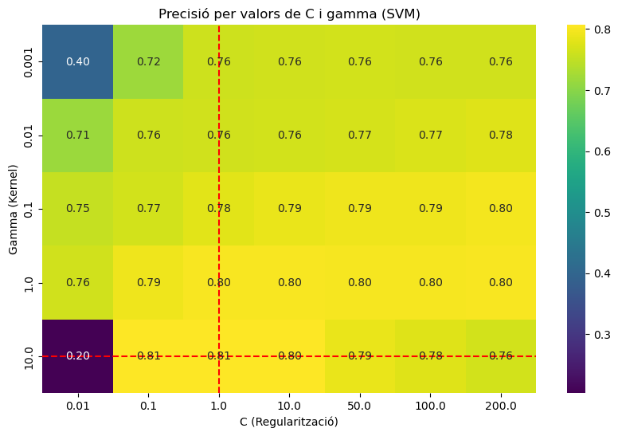

```python
import time

start_time = time.time()

param_grid = {
    'C': [0.01, 0.1, 1, 10, 50, 100, 200],
    'gamma': [0.001, 0.01, 0.1, 1, 10],
    'kernel': ['rbf']
}

svc = SVC()
grid_search_svm = GridSearchCV(estimator=svc, param_grid=param_grid, cv=4, scoring='accuracy', verbose=1, n_jobs=-1)
grid_search_svm.fit(X_train_projection, y_train)
elapsed_time = time.time() - start_time
print(f"Temps total d'execució: {elapsed_time:.2f} segons")
results_svm = pd.DataFrame(grid_search_svm.cv_results_)

#millors hiperparàmetres
best_params_svm = grid_search_svm.best_params_
best_score_svm = grid_search_svm.best_score_
print(f"Millors hiperparàmetres: {best_params_svm}")
print(f"Millor precisió amb validació creuada: {best_score_svm:.2f}")

# Validació amb test
best_model_svm = grid_search_svm.best_estimator_
test_accuracy = best_model_svm.score(X_test_projection, y_test)
print(f"Precisió en el conjunt de test: {test_accuracy:.2f}")

# Mostrar mitjana i desviació estàndard
print("-------------------------------------------------------")
for _, row in results_svm.iterrows():
    print(f"C={row['param_C']}, gamma={row['param_gamma']}: mean={row['mean_test_score']:.4f}, std={row['std_test_score']:.4f}")

#heatmap
pivot_data_svm = results_svm.pivot(index='param_gamma', columns='param_C', values='mean_test_score')

plt.figure(figsize=(10, 6))
sns.heatmap(pivot_data_svm, annot=True, fmt=".2f", cmap='viridis', cbar=True)
plt.title("Precisió per valors de C i gamma (SVM)")
plt.xlabel("C (Regularització)")
plt.ylabel("Gamma (Kernel)")
plt.axvline(pivot_data_svm.columns.get_loc(best_params_svm['C']) + 0.5, color='red', linestyle='--', label=f"Millor C: {best_params_svm['C']}")
plt.axhline(pivot_data_svm.index.get_loc(best_params_svm['gamma']) + 0.5, color='red', linestyle='--', label=f"Millor gamma: {best_params_svm['gamma']}")
plt.show()
```

**Implementació:**

Realitza els passos següents amb el dataset d’entrenament (*train*):

1. Entrena un model SVM utilitzant la millor combinació de paràmetres que hagis trobat.
2. Calcula l’*accuracy* (precisió) del model tant en les dades de *train* com en les de *test*.
3. Calcula la matriu de confusió utilitzant les dades de *test*.
4. Representa gràficament la frontera de decisió amb les dades de *test*.

Aquest procés et permetrà veure com la millor combinació de paràmetres millora l’eficàcia del teu model SVM en la classificació de les dades.

**Solució:**

```
Train Accuracy (Best SVM): 0.84
Test Accuracy (Best SVM): 0.79
Matriu de confusió (Best SVM - conjunt de test):
[[176   0  10  21   5]
 [  1 171   0  12   2]
 [  4   0 130   0  60]
 [ 14   1   8 166  16]
 [  1   0  49   9 144]]
```

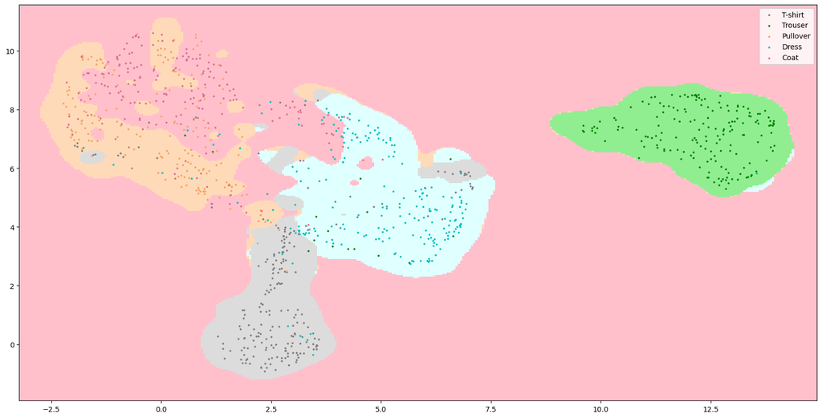

```python
best_C = 1
best_gamma = 10

#SVM millors paràmetres
best_svm = SVC(kernel='rbf', C=best_C, gamma=best_gamma)
best_svm.fit(X_train_projection, y_train)

# Predicció i càlcul de l’accuracy
y_train_pred_svm = best_svm.predict(X_train_projection)
y_test_pred_svm = best_svm.predict(X_test_projection)

train_accuracy_svm = accuracy_score(y_train, y_train_pred_svm)
test_accuracy_svm = accuracy_score(y_test, y_test_pred_svm)

print(f"Train Accuracy (Best SVM): {train_accuracy_svm:.2f}")
print(f"Test Accuracy (Best SVM): {test_accuracy_svm:.2f}")

# Matriu de confusió
conf_matrix_svm = confusion_matrix(y_test, y_test_pred_svm)
print("Matriu de confusió (Best SVM - conjunt de test):")
print(conf_matrix_svm)

# gràfic
plot_decision_boundaries(best_svm, X_test_projection, y_test)
```

**Anàlisi:**

1. Comenta els resultats obtinguts en la cerca dels millors hiperparàmetres. Reflexiona sobre com ha variat el rendiment del model SVM amb els diferents valors de *C* i *gamma*. Considera si els valors òptims trobats tenen sentit en el context del teu conjunt de dades.
2. Examina les fronteres de decisió que has generat amb el model SVM. És coherent la forma d’aquestes fronteres amb el que esperaries de l’algorisme utilitzat? Pensa en com la combinació d’hiperparàmetres seleccionats podria influir en la forma de les fronteres.
3. Avalua les prediccions realitzades sobre el conjunt de test. Observa la seva precisió i com es distribueixen en relació amb les fronteres de decisió. Són aquestes prediccions consistents amb el que observes a les fronteres de decisió?

Aquesta anàlisi t’ajudarà a comprendre l’eficàcia del model SVM amb els hiperparàmetres seleccionats i el seu impacte en la classificació de les dades.

**Resposta:**

La cerca dels millors hiperparàmetres ha identificat que C=1 i gamma=10 són òptims, obtenint una precisió màxima de validació creuada de 0.81. Aquests valors indiquen un compromís adequat entre un marge ampli (C moderat) i la influència local de les mostres (gamma alt), permetent capturar patrons complexos del conjunt de dades.

Les fronteres de decisió generades són coherents amb les propietats de l'algorisme SVM amb kernel RBF. Presenten formes corbes i adaptatives, capturant zones amb solapaments moderats. Això confirma que la combinació de C=1 i gamma=10 permet una bona separació entre classes amb variabilitat significativa.

Pel que fa a les prediccions, la precisió sobre el conjunt de test (0.79) està alineada amb la validació creuada, confirmant que el model no està sobreajustat. La matriu de confusió revela un bon rendiment en classes com Trouser i Dress, mentre que hi ha més confusió en Pullover i Coat, degut al seu solapament. Les mostres estan majoritàriament ben classificades, en línia amb les fronteres observades, indicant que el model generalitza correctament.

## 1.6. Arbres de decisió (1 punt)

En aquesta secció, exploraràs els arbres de decisió, models predictius que es basen en regles binàries (sí/no) per classificar les observacions segons els seus atributs i predir el valor de la variable resposta. Aquests arbres poden ser classificadors, com en el teu exemple, o regressors per predir variables contínues.

#### Construcció d’un Arbre

Per construir un arbre, segueix l’algorisme de *recursive binary splitting*:

1. Comença a la part superior de l’arbre, on totes les observacions pertanyen a la mateixa regió.
2. Identifica tots els possibles punts de tall per a cadascun dels predictors. Aquests punts de tall són els diferents nivells dels predictors.
3. Avalua les possibles divisions per a cada predictor utilitzant una mesura específica. En els classificadors, aquestes mesures poden ser el *classification error rate*, l’índex Gini, l’entropia o el chi-square.

Comprendre aquests passos t’ajudarà a entendre com els arbres de decisió creen divisions binàries per classificar les dades i com es poden aplicar tant per a classificació com per a regressió.

**Implementación:**

Sigue estos pasos:

1. Con el dataset de entrenamiento (*train*), entrena un árbol de decisión utilizando el clasificador `DecisionTreeClassifier` de la biblioteca `tree` de `sklearn`.
2. Calcula el *accuracy* (precisión) del modelo tanto en los datos de *train* como de *test*.
3. Calcula la matriz de confusión utilizando los datos de *test*.
4. Representa gráficamente la frontera de decisión con los datos de *test*.
5. Representa el árbol de decisión. Puedes utilizar el comando `plot.tree` de la biblioteca `tree` de `sklearn`.

Estos pasos te permitirán evaluar cómo el árbol de decisión se comporta en tu conjunto de datos, tanto en términos de clasificación como en su representación visual."

**Solució:**

```
Temps total d'entrenament: 0.01 segons
Train Accuracy (Pruned Decision Tree): 1.00
Test Accuracy (Pruned Decision Tree): 0.73
Matriu de confusió (Pruned Decision Tree - conjunt de test):
[[173   3  10  19   7]
 [  2 169   2  11   2]
 [  6   1 117   4  66]
 [ 15   3  12 158  17]
 [  4   1  75  10 113]]
```

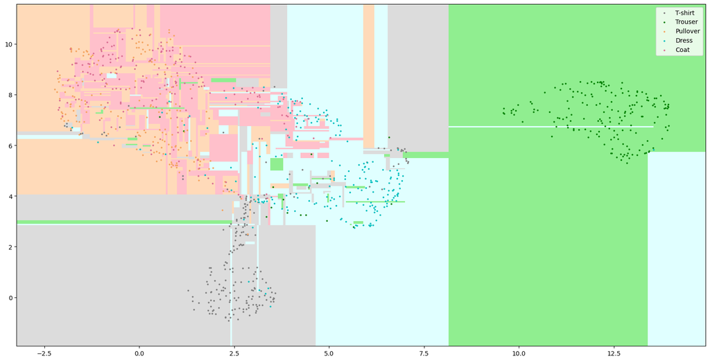

[figure not shown]

```python
from sklearn.tree import DecisionTreeClassifier, plot_tree
import matplotlib.pyplot as plt

# arbre de decisió
start_time = time.time()
model_tree_pruned = DecisionTreeClassifier(random_state=24)
model_tree_pruned.fit(X_train_projection, y_train)
elapsed_time = time.time() - start_time
print(f"Temps total d'entrenament: {elapsed_time:.2f} segons")
# Predicció i càlcul de l’accuracy
y_train_pred_tree_pruned = model_tree_pruned.predict(X_train_projection)
y_test_pred_tree_pruned = model_tree_pruned.predict(X_test_projection)

train_accuracy_tree_pruned = accuracy_score(y_train, y_train_pred_tree_pruned)
test_accuracy_tree_pruned = accuracy_score(y_test, y_test_pred_tree_pruned)

print(f"Train Accuracy (Pruned Decision Tree): {train_accuracy_tree_pruned:.2f}")
print(f"Test Accuracy (Pruned Decision Tree): {test_accuracy_tree_pruned:.2f}")

# Matriu de confusió
conf_matrix_tree_pruned = confusion_matrix(y_test, y_test_pred_tree_pruned)
print("Matriu de confusió (Pruned Decision Tree - conjunt de test):")
print(conf_matrix_tree_pruned)

plot_decision_boundaries(model_tree_pruned, X_test_projection, y_test)
plt.figure(figsize=(20, 10))
plot_tree(
    model_tree_pruned,
    feature_names=["Component 1", "Component 2"],
    class_names=[f"Classe {i}" for i in range(len(np.unique(y_train)))],
    filled=True
)
plt.title("Arbre de Decisió Pruned")
plt.show()
```

**Anàlisi:**

1. **Avalua i comenta els resultats:** Analitza l’*accuracy* del model en els conjunts de *train* i *test*. Si el model té un *accuracy* molt alt en *train* però significativament més baix en *test*, això pot indicar overfitting. A més, revisa la matriu de confusió per identificar si hi ha desequilibris en les classificacions correctes i errors per classe.
2. **Reflexiona sobre la frontera de decisió:** Observa si la frontera de decisió al conjunt de *test* mostra patrons abruptes o sobrecomplexos. Aquesta característica és coherent amb el que esperaries d’un arbre de decisió, especialment si està profundament ajustat al conjunt de *train*.
3. **Observa la representació gràfica de l’arbre:** Analitza com les ramificacions mostren les decisions preses pel model. Busca si hi ha nodes fulla amb un nombre molt reduït d’observacions o divisions molt específiques que podrien indicar sobreajustament. Comprova si les regles de classificació són intuïtives i si reflecteixen els patrons esperats en el conjunt de dades.

Aquesta anàlisi t’ajudarà a identificar possibles ajustaments al model per millorar la seva capacitat de generalització i la seva eficàcia global.

**Resposta:**

El model mostra un clar overfitting, amb una precisió del 100% en train però només del 73% en test, indicant que el model no generalitza bé. La matriu de confusió revela desequilibris, especialment en Pullover i Coat, amb nombroses confusions entre aquestes classes. Això suggereix que el model ha memoritzat patrons específics d'entrenament en lloc de capturar relacions generals.

La frontera de decisió al conjunt de test mostra patrons abruptes i fragmentats, típics d’un arbre de decisió profundament ajustat. Aquesta complexitat reflecteix que el model ha memoritzat detalls específics del conjunt de train enlloc de generalitzar. És coherent amb la naturalesa d’un arbre no optimitzat, especialment quan es permet una profunditat excessiva sense restriccions.

La representació gràfica de l’arbre mostra una estructura altament ramificada, amb nodes fulla que contenen poques observacions i divisions molt específiques. Això és un indicador clar de sobreajustament, ja que el model crea regles excessivament complexes per ajustar-se als detalls de train. Aquestes regles no són intuïtives i s’han adaptat massa a les peculiaritats de les dades d’entrenament.

#### Evitant el *overfitting*

El procés de construcció d’arbres descrit tendeix a reduir ràpidament l’error d’entrenament, de manera que, generalment, el model s’ajusta molt bé a les observacions utilitzades com a entrenament (conjunt de *train*). Com a conseqüència, els arbres de decisió tendeixen a l’*overfitting*.

Per evitar l’*overfitting* en els arbres de decisió, és crucial que modifiquis certs hiperparàmetres del model de la manera següent:

1. Utilitza l’hiperparàmetre `max_depth`, que defineix la profunditat màxima de l’arbre. Hauràs d’explorar els valors entre 4 i 10 per trobar l’equilibri adequat entre la complexitat del model i la seva capacitat per generalitzar.
2. Estableix l’hiperparàmetre `min_samples_split`, que és el nombre mínim d’observacions que ha de tenir una fulla de l’arbre abans de considerar una divisió. Experimenta amb valors com 2, 10, 20, 50 i 100 per assegurar-te que l’arbre no es torni massa específic per a les observacions d’entrenament.

Ajustant aquests hiperparàmetres, podràs controlar la tendència de l’arbre de decisió a sobreajustar-se al conjunt d’entrenament, millorant així la seva capacitat per fer prediccions efectives en dades noves.

**Implementació:**

1. Calcula el valor òptim dels hiperparàmetres `max_depth` i `min_samples_split` utilitzant una cerca de graella amb validació creuada. Aquest procés t’ajudarà a trobar els valors òptims que evitaran el sobreajustament.
2. Per a cada combinació de valors, calcula la seva mitjana i desviació estàndard.
3. Fes un *heatmap* per visualitzar la precisió segons els diferents valors dels hiperparàmetres.

Utilitza el mòdul `GridSearchCV` de `sklearn` per calcular els millors hiperparàmetres amb el classificador `DecisionTreeClassifier` de `tree` de `sklearn`. Per a la visualització del *heatmap*, fes servir la biblioteca `Seaborn`.

Aquests passos et permetran identificar de manera efectiva i visual els valors de `max_depth` i `min_samples_split` que maximitzen la precisió del teu arbre de decisió, minimitzant el risc de sobreajustament.

**Solució:**

```
Temps total d'execució: 1.31 segons
Millors hiperparàmetres: {'max_depth': 10, 'min_samples_split': 100}
Millor precisió amb validació creuada: 0.79
```

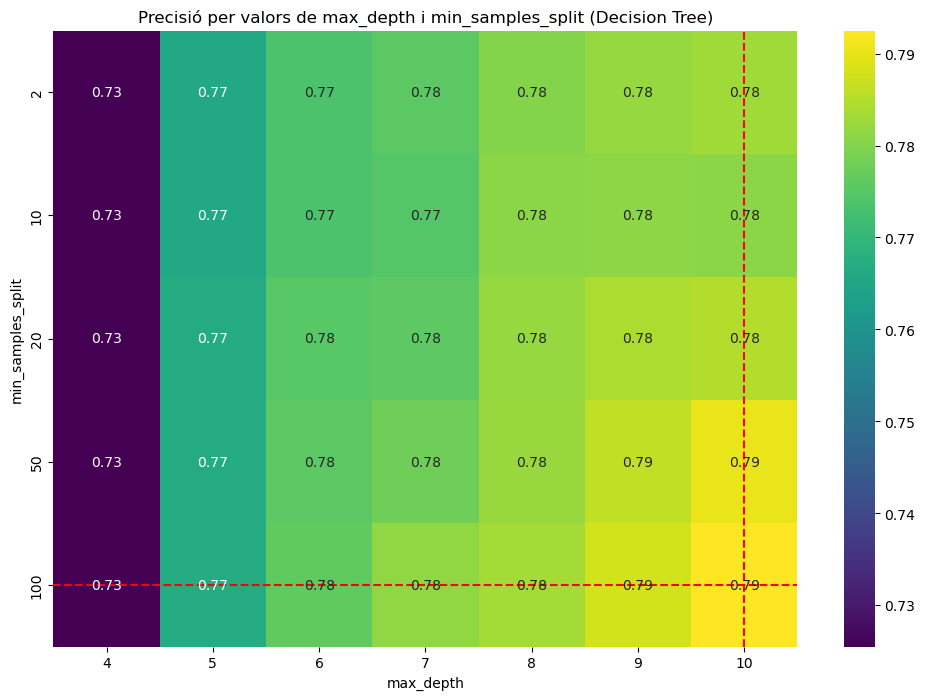

```python
start_time = time.time()

param_grid_tree = {
    'max_depth': range(4, 11),
    'min_samples_split': [2, 10, 20, 50, 100]
}

model_tree_cv = DecisionTreeClassifier(random_state=24)
grid_search_tree = GridSearchCV(
    estimator=model_tree_cv,
    param_grid=param_grid_tree,
    cv=5,
    scoring='accuracy',
    return_train_score=True
)
grid_search_tree.fit(X_train_projection, y_train)

elapsed_time = time.time() - start_time
print(f"Temps total d'execució: {elapsed_time:.2f} segons")

results_tree = pd.DataFrame(grid_search_tree.cv_results_)

best_params_tree = grid_search_tree.best_params_
best_score_tree = grid_search_tree.best_score_

print(f"Millors hiperparàmetres: {best_params_tree}")
print(f"Millor precisió amb validació creuada: {best_score_tree:.2f}")

#  heatmap
pivot_data_tree = results_tree.pivot(index='param_min_samples_split', columns='param_max_depth', values='mean_test_score')

plt.figure(figsize=(12, 8))
sns.heatmap(pivot_data_tree, annot=True, fmt=".2f", cmap='viridis', cbar=True)
plt.title("Precisió per valors de max_depth i min_samples_split (Decision Tree)")
plt.xlabel("max_depth")
plt.ylabel("min_samples_split")
plt.axvline(pivot_data_tree.columns.get_loc(best_params_tree['max_depth']) + 0.5, color='red', linestyle='--', label=f"Millor max_depth: {best_params_tree['max_depth']}")
plt.axhline(pivot_data_tree.index.get_loc(best_params_tree['min_samples_split']) + 0.5, color='red', linestyle='--', label=f"Millor min_samples_split: {best_params_tree['min_samples_split']}")
plt.show()
```

**Implementació:**

1. Entrena un arbre de decisió amb el dataset d’entrenament (*train*) utilitzant la millor combinació de paràmetres que hagis trobat.
2. Calcula l’*accuracy* (precisió) del model tant en les dades de *train* com en les de *test*.
3. Calcula la matriu de confusió utilitzant les dades de *test*.
4. Representa gràficament la frontera de decisió amb les dades de *test*.
5. Representa l’arbre de decisió.

Aquests passos et permetran avaluar com l’arbre de decisió, ajustat amb els hiperparàmetres òptims, es comporta en el teu conjunt de dades, tant en termes de classificació com en la seva representació visual.

**Solució:**

```
Temps total d'entrenament: 0.01 segons
Train Accuracy (Best Decision Tree): 0.82
Test Accuracy (Best Decision Tree): 0.78
Matriu de confusió (Best Decision Tree - conjunt de test):
[[176   0  14  17   5]
 [  1 170   2  12   1]
 [  3   0 130   0  61]
 [  9   1   8 169  18]
 [  0   0  55  13 135]]
```

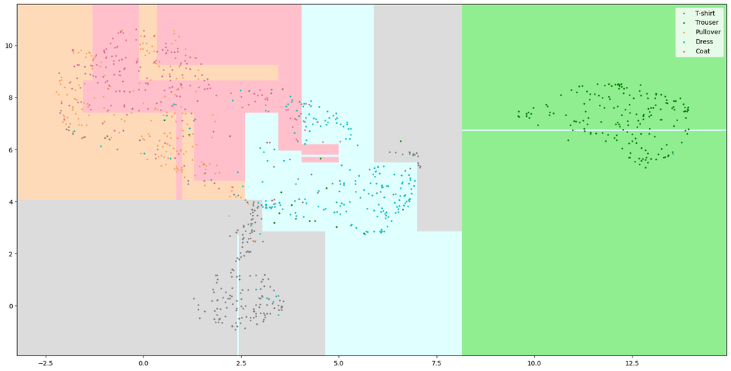

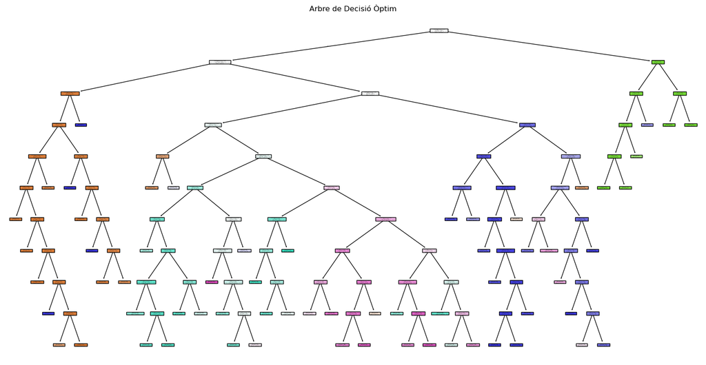

```python
# Entrenar l'arbre de decisió
start_time = time.time()
best_tree = DecisionTreeClassifier(max_depth=10, min_samples_split=100, random_state=random_state)
best_tree.fit(X_train_projection, y_train)
elapsed_time = time.time() - start_time
print(f"Temps total d'entrenament: {elapsed_time:.2f} segons")

# Predicció i càlcul de l'accuracy
y_train_pred_tree = best_tree.predict(X_train_projection)
y_test_pred_tree = best_tree.predict(X_test_projection)

train_accuracy_tree = accuracy_score(y_train, y_train_pred_tree)
test_accuracy_tree = accuracy_score(y_test, y_test_pred_tree)

print(f"Train Accuracy (Best Decision Tree): {train_accuracy_tree:.2f}")
print(f"Test Accuracy (Best Decision Tree): {test_accuracy_tree:.2f}")

# Matriu de confusió
conf_matrix_best_tree = confusion_matrix(y_test, y_test_pred_tree)
print("Matriu de confusió (Best Decision Tree - conjunt de test):")
print(conf_matrix_best_tree)

plot_decision_boundaries(best_tree, X_test_projection, y_test)

plt.figure(figsize=(20, 10))
plot_tree(
    best_tree,
    feature_names=["Component 1", "Component 2"],
    class_names=[f"Classe {i}" for i in range(len(np.unique(y_train)))],
    filled=True
)
plt.title("Arbre de Decisió Òptim")
plt.show()
```

**Anàlisi:**

1. Avalua i comenta els resultats obtinguts en la cerca dels millors hiperparàmetres. Considera com la combinació òptima de `max_depth` i `min_samples_split` ha impactat en el rendiment de l’arbre de decisió.
2. Examina les fronteres de decisió generades amb el conjunt de *test*. Reflexiona si la forma d’aquestes fronteres és coherent amb el que esperaries d’un arbre de decisió configurat amb aquests hiperparàmetres.
3. Analitza les prediccions realitzades sobre el conjunt de *test*. Observa la seva precisió i com es distribueixen en relació amb les fronteres de decisió. Són consistents aquestes prediccions amb l’estructura de l’arbre de decisió i les fronteres observades?

Aquesta anàlisi t’ajudarà a comprendre l’eficàcia de l’arbre de decisió amb els hiperparàmetres seleccionats i el seu impacte en la classificació de les dades.

**Resposta:**

La cerca dels hiperparàmetres òptims ha identificat que max_depth=10 i min_samples_split=100 són adequats per equilibrar la complexitat i la generalització de l’arbre de decisió. Amb aquests valors, el model obté una precisió del 82% en train i del 78% en test, indicant una millora significativa en la capacitat de generalitzar en comparació amb l'arbre sense restriccions.

Les fronteres de decisió són coherents amb un arbre configurat amb una profunditat màxima moderada. Mostren divisions clares i definides, tot i que encara hi ha confusió en zones on les classes es solapen. Aquesta fragmentació és menor que en arbres profundament ajustats, demostrant l'eficàcia de limitar els hiperparàmetres.

Les prediccions al conjunt de test mostren una precisió del 78%, coherent amb les fronteres de decisió generades per l’arbre configurat. La majoria de classes estan ben separades, però hi ha confusió significativa entre Pullover i Coat, reflectint el solapament observat en les fronteres. Les prediccions són consistents amb l’estructura de l’arbre, que captura patrons generals però té dificultats en zones amb més complexitat. Això confirma que l’arbre, tot i ser òptim, no és suficient per classes altament solapades.

# 2. Implementació del cas pràctic (5 punts)

Avui dia, la logística de l’última milla és un problema abordat a la indústria per moltes empreses dedicades al comerç electrònic. La informació proporcionada a l’usuari a l’hora de fer una comanda pot suposar un valor diferencial. Per això, moltes empreses dediquen molts recursos per oferir una estimació precisa sobre el temps que trigarà a arribar cada comanda. En aquest exercici ens centrarem a predir el nivell de servei de les operacions logístiques de l’última milla d’Amazon. En concret, identificarem aquelles entregues que es considerin premium (temps de repartiment inferior a dues hores).

Per fer-ho, utilitzarem el conjunt de dades d’entregues amazon-delivery-dataset, el qual inclou dades sobre més de 43.632 entregues en diverses ciutats, amb informació rellevant sobre els detalls de la comanda, els agents de lliurament, les condicions meteorològiques i del trànsit, i les mètriques de rendiment del lliurament. En concret, el dataset conté 16 característiques:

- Order_ID: identificador únic de comanda
- Agent_Age: edat de l’agent (repartidor)
- Agent_Rating: puntuació de l’agent (repartidor)
- Store_Latitude: latitud del magatzem o botiga
- Store_Longitude: longitud del magatzem o botiga
- Drop_Latitude: latitud del client
- Drop_Longitude: longitud del client
- Order_Date: data de la comanda
- Order_Time: hora de la comanda
- Pickup_Time: hora a la qual la comanda va ser recollida per al seu lliurament
- Weather: informació sobre la climatologia
- Traffic: informació sobre el trànsit
- Vehicle: informació sobre el vehicle
- Area: informació sobre l’àrea de repartiment
- Category: categoria dels productes de la comanda
- Delivery_Time: temps de lliurament (minuts)

L’objectiu d’aquesta secció és abordar l’anàlisi d’aquest conjunt de dades i entrenar una xarxa neuronal (Perceptró Multicapa) per predir el nivell de servei. Aquí tens alguns passos que podries seguir:

1. **Anàlisi Exploratori de Dades (EDA)**: Comença explorant el conjunt de dades per entendre’n l’estructura i distribució. Analitza la proporció de cada classe. Observa la distribució de les diferents característiques i la seva relació amb la classe objectiu "class".
2. **Preprocessament de Dades**: Considera normalitzar les característiques perquè estiguin a la mateixa escala que les components principals.
3. **Modelització**: Utilitza un perceptró multicapa com a eina de classificació. Atès que l’objectiu és identificar el nivell de servei del lliurament, és vital centrar-se en mètriques com la precisió, la sensibilitat (*recall*), el valor F1 i l’àrea sota la corba ROC (AUC-ROC

## 2.1. Càrrega de dades i processament inicial (0.5 punts)

El primer que has de fer és carregar el conjunt de dades i visualitzar informació rellevant del mateix. Assegura’t de verificar el següent:

1. Confirma la quantitat total de files i columnes al DataFrame.
2. Revisa el nom de cada columna del DataFrame.
3. Verifica el nombre de valors no nuls en cada columna.
4. Identifica el tipus de dades de cada columna, que pot ser int, float, object, entre d’altres.
5. Comprova la quantitat de memòria utilitzada pel DataFrame.

Aquests passos et proporcionaran una comprensió inicial clara i detallada del conjunt de dades amb el qual estàs treballant.

```python
root_path = kagglehub.dataset_download("sujalsuthar/amazon-delivery-dataset")
dataset_path = os.path.join(root_path, "amazon_delivery.csv")
data = pd.read_csv(dataset_path)
```

```python
print(f"Nombre de files i columnes: {data.shape}")
```

```
Nombre de files i columnes: (43739, 16)
```

```python
print("\nNoms de les Columnes :")
print(data.columns.tolist())
```

```
Noms de les Columnes :
['Order_ID', 'Agent_Age', 'Agent_Rating', 'Store_Latitude', 'Store_Longitude', 'Drop_Latitude', 'Drop_Longitude', 'Order_Date', 'Order_Time', 'Pickup_Time', 'Weather', 'Traffic', 'Vehicle', 'Area', 'Delivery_Time', 'Category']
```

```python
print("\nInfo de columnes :")
print(data.info())
```

```
Info de columnes :
<class 'pandas.core.frame.DataFrame'>
RangeIndex: 43739 entries, 0 to 43738
Data columns (total 16 columns):
 #   Column           Non-Null Count  Dtype
---  ------           --------------  -----
 0   Order_ID         43739 non-null  object
 1   Agent_Age        43739 non-null  int64
 2   Agent_Rating     43685 non-null  float64
 3   Store_Latitude   43739 non-null  float64
 4   Store_Longitude  43739 non-null  float64
 5   Drop_Latitude    43739 non-null  float64
 6   Drop_Longitude   43739 non-null  float64
 7   Order_Date       43739 non-null  object
 8   Order_Time       43739 non-null  object
 9   Pickup_Time      43739 non-null  object
 10  Weather          43648 non-null  object
 11  Traffic          43739 non-null  object
 12  Vehicle          43739 non-null  object
 13  Area             43739 non-null  object
 14  Delivery_Time    43739 non-null  int64
 15  Category         43739 non-null  object
dtypes: float64(5), int64(2), object(9)
memory usage: 5.3+ MB
None
```

```python
print("\nTipus de Dades de Cada Columna :")
print(data.dtypes)
```

```
Tipus de Dades de Cada Columna :
Order_ID            object
Agent_Age            int64
Agent_Rating       float64
Store_Latitude     float64
Store_Longitude    float64
Drop_Latitude      float64
Drop_Longitude     float64
Order_Date          object
Order_Time          object
Pickup_Time         object
Weather             object
Traffic             object
Vehicle             object
Area                object
Delivery_Time        int64
Category            object
dtype: object
```

```python
print("\nMemòria Utilitzada pel Dataset :")
print(data.memory_usage(deep=True).sum() / (1024**2), "MB")
```

```
Memòria Utilitzada pel Dataset :
26.989195823669434 MB
```

```python
print("\nPrimeres Files del Dataset :")
data.head()
```

```
Primeres Files del Dataset :
```

|  | Order_ID | Agent_Age | Agent_Rating | Store_Latitude | Store_Longitude | Drop_Latitude | Drop_Longitude | Order_Date | Order_Time | Pickup_Time | Weather | Traffic | Vehicle | Area | Delivery_Time | Category |
| --- | --- | --- | --- | --- | --- | --- | --- | --- | --- | --- | --- | --- | --- | --- | --- | --- |
| 0 | ialx566343618 | 37 | 4.9 | 22.745049 | 75.892471 | 22.765049 | 75.912471 | 2022-03-19 | 11:30:00 | 11:45:00 | Sunny | High | motorcycle | Urban | 120 | Clothing |
| 1 | akqg208421122 | 34 | 4.5 | 12.913041 | 77.683237 | 13.043041 | 77.813237 | 2022-03-25 | 19:45:00 | 19:50:00 | Stormy | Jam | scooter | Metropolitian | 165 | Electronics |
| 2 | njpu434582536 | 23 | 4.4 | 12.914264 | 77.678400 | 12.924264 | 77.688400 | 2022-03-19 | 08:30:00 | 08:45:00 | Sandstorms | Low | motorcycle | Urban | 130 | Sports |
| 3 | rjto796129700 | 38 | 4.7 | 11.003669 | 76.976494 | 11.053669 | 77.026494 | 2022-04-05 | 18:00:00 | 18:10:00 | Sunny | Medium | motorcycle | Metropolitian | 105 | Cosmetics |
| 4 | zguw716275638 | 32 | 4.6 | 12.972793 | 80.249982 | 13.012793 | 80.289982 | 2022-03-26 | 13:30:00 | 13:45:00 | Cloudy | High | scooter | Metropolitian | 150 | Toys |

**Implementació:**

Com es pot observar, no disposem del nivell de servei en el conjunt de dades. Per això, definirem que totes les entregues realitzades en un màxim de dues hores han tingut un servei Premium. Per fer-ho, crea una nova columna denominada "Premium_Delivery", que contingui el valor 1 si l’entrega s’ha realitzat en un màxim de 120 minuts, i un 0 en cas contrari. És important assegurar que el tipus de la nova columna sigui enter.

**Solució:**

```python
# Crear la columna "Premium_Delivery"
data['Premium_Delivery'] = (data['Delivery_Time'] <= 120).astype(int)

print("premium_delivery type = ", data['Premium_Delivery'].dtype)
data.head()
```

```
premium_delivery type =  int32
```

|  | Order_ID | Agent_Age | Agent_Rating | Store_Latitude | Store_Longitude | Drop_Latitude | Drop_Longitude | Order_Date | Order_Time | Pickup_Time | Weather | Traffic | Vehicle | Area | Delivery_Time | Category | Premium_Delivery |
| --- | --- | --- | --- | --- | --- | --- | --- | --- | --- | --- | --- | --- | --- | --- | --- | --- | --- |
| 0 | ialx566343618 | 37 | 4.9 | 22.745049 | 75.892471 | 22.765049 | 75.912471 | 2022-03-19 | 11:30:00 | 11:45:00 | Sunny | High | motorcycle | Urban | 120 | Clothing | 1 |
| 1 | akqg208421122 | 34 | 4.5 | 12.913041 | 77.683237 | 13.043041 | 77.813237 | 2022-03-25 | 19:45:00 | 19:50:00 | Stormy | Jam | scooter | Metropolitian | 165 | Electronics | 0 |
| 2 | njpu434582536 | 23 | 4.4 | 12.914264 | 77.678400 | 12.924264 | 77.688400 | 2022-03-19 | 08:30:00 | 08:45:00 | Sandstorms | Low | motorcycle | Urban | 130 | Sports | 0 |
| 3 | rjto796129700 | 38 | 4.7 | 11.003669 | 76.976494 | 11.053669 | 77.026494 | 2022-04-05 | 18:00:00 | 18:10:00 | Sunny | Medium | motorcycle | Metropolitian | 105 | Cosmetics | 1 |
| 4 | zguw716275638 | 32 | 4.6 | 12.972793 | 80.249982 | 13.012793 | 80.289982 | 2022-03-26 | 13:30:00 | 13:45:00 | Cloudy | High | scooter | Metropolitian | 150 | Toys | 0 |

**Implementació:**

Per simplificar l’exercici i facilitar-ne la comprensió, s’han d’eliminar les següents columnes: Order_ID, Order_Date, Order_Time i Pickup_Time.

**Solució:**

```python
# Eliminar les columnes especificades
columns_to_drop = ['Order_ID', 'Order_Date', 'Order_Time', 'Pickup_Time']
data = data.drop(columns=columns_to_drop)

# Verificar les columnes restants
remaining_columns = data.columns.tolist()
remaining_columns
```

```
['Agent_Age',
 'Agent_Rating',
 'Store_Latitude',
 'Store_Longitude',
 'Drop_Latitude',
 'Drop_Longitude',
 'Weather',
 'Traffic',
 'Vehicle',
 'Area',
 'Delivery_Time',
 'Category',
 'Premium_Delivery']
```

**Implementació:**

A continuació, calcularem la distància haversiana en quilòmetres entre el magatzem i el client. Per fer-ho, hem de crear una nova columna anomenada "Distance" i eliminar les quatre columnes relacionades amb les coordenades.

**Solució:**

```python
# funcio de la formula haversiana
def haversine(lat1, lon1, lat2, lon2):
    # Convertir graus a radians
    lat1, lon1, lat2, lon2 = map(np.radians, [lat1, lon1, lat2, lon2])
    # Diferències entre les coordenades
    dlat = lat2 - lat1
    dlon = lon2 - lon1
    # Fórmula haversiana
    a = np.sin(dlat / 2.0)**2 + np.cos(lat1) * np.cos(lat2) * np.sin(dlon / 2.0)**2
    c = 2 * np.arcsin(np.sqrt(a))
    # Radi de la Terra en quilòmetres
    radius_earth_km = 6371.0
    return radius_earth_km * c

# Aplicar la fórmula haversiana
data['Distance'] = haversine(
    data['Store_Latitude'],
    data['Store_Longitude'],
    data['Drop_Latitude'],
    data['Drop_Longitude']
)

columns_to_remove = ['Store_Latitude', 'Store_Longitude', 'Drop_Latitude', 'Drop_Longitude']
data = data.drop(columns=columns_to_remove)


data[['Distance']].head()
```

|  | Distance |
| --- | --- |
| 0 | 3.025149 |
| 1 | 20.183530 |
| 2 | 1.552758 |
| 3 | 7.790401 |
| 4 | 6.210138 |

## 2.2. Anàlisi Exploratori de Dades (EDA) (1.25 punts)

L’Anàlisi Exploratori de Dades (EDA, per les seves sigles en anglès) en ciència de dades és un enfocament inicial per comprendre i resumir el contingut d’un conjunt de dades. Aquest procés implica diverses tècniques i passos:

1. **Inspecció de Dades**: Es comença revisant les dades brutes per identificar-ne l’estructura, la mida i el tipus (com numèric, categòric). Això inclou detectar valors faltants o inusuals.
2. **Resum Estadístic**: Es calculen estadístiques descriptives com la mitjana, mediana, rang, variància i desviació estàndard per obtenir una idea general de les tendències i patrons en les dades.
3. **Visualització de Dades**: S’utilitzen gràfics i diagrames (com histogrames, gràfics de caixa, diagrames de dispersió) per visualitzar distribucions, relacions entre variables i possibles anomalies. Això ajuda a comprendre millor les dades i a identificar patrons o irregularitats.
4. **Anàlisi de Relacions i Correlacions**: S’exploren les relacions entre diferents variables per entendre com s’influeixen entre si. Això pot implicar l’ús de matrius de correlació i gràfics de dispersió.
5. **Identificació de Patrons i Anomalies**: Es busquen patrons consistents o anomalies (com valors atípics) que puguin suggerir tendències o problemes en les dades.

L’EDA és una fase crítica en qualsevol projecte de ciència de dades, ja que proporciona una comprensió profunda i una base sòlida per a posteriors anàlisis i modelatge.

**Implementació:**

1. Calcula les freqüències de la variable objectiu (`Premium_Delivery`) en el teu conjunt de dades.
2. Crea un gràfic de barres per visualitzar aquestes freqüències. Això t’ajudarà a entendre la proporció d’entregues premium en comparació amb les que no ho són.

A continuació, analitza la distribució de les variables numèriques:

1. Representa gràficament l’histograma de les variables, separant les observacions segons la classe a la qual pertanyen (premium o no).
2. Organitza tots els histogrames en un format de 4 files i 1 columna. Això facilitarà la comparació visual de les distribucions per a cada classe en cada variable.

Per últim, analitza la distribució de les variables categòriques de forma anàloga a les variables numèriques, organitzant tots els histogrames en un format de 5 files i 1 columna.

Aquests passos et permetran obtenir una visió més clara de l’estructura del teu conjunt de dades i com les diferents variables poden influir en la identificació de les entregues premium.

**Solució:**

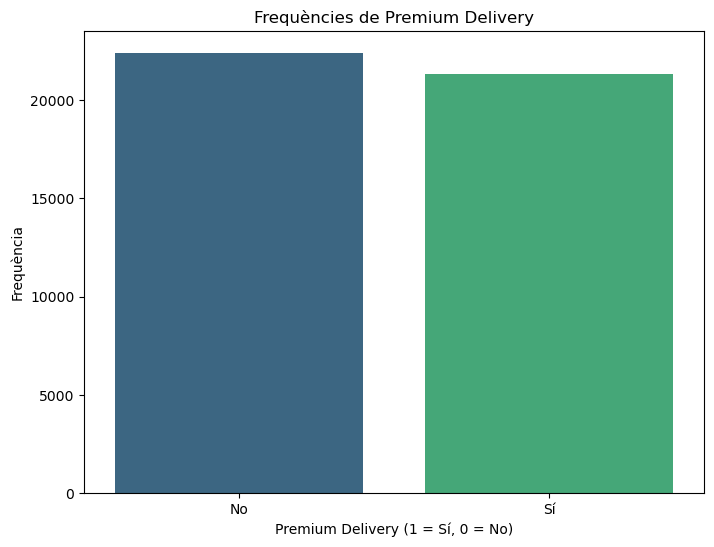

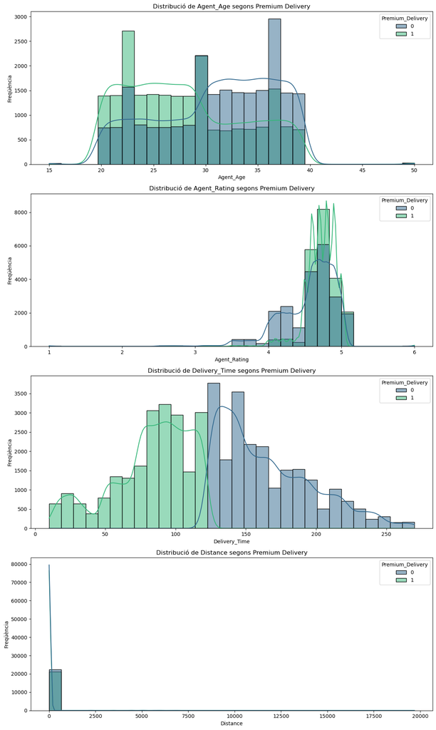

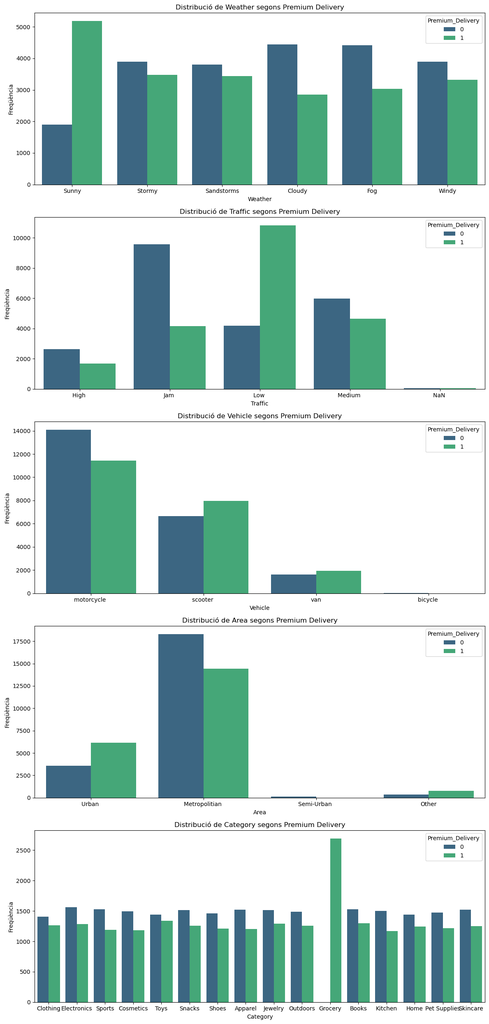

```python
import matplotlib.pyplot as plt
import seaborn as sns

premium_delivery_counts = data['Premium_Delivery'].value_counts()

plt.figure(figsize=(8, 6))
sns.barplot(x=premium_delivery_counts.index, y=premium_delivery_counts.values, palette="viridis")
plt.title("Frequències de Premium Delivery")
plt.xlabel("Premium Delivery (1 = Sí, 0 = No)")
plt.ylabel("Frequència")
plt.xticks([0, 1], ["No", "Sí"])
plt.show()

# Anàlisi de les variables numèriques
numeric_columns = data.select_dtypes(include=['int64', 'float64']).columns

plt.figure(figsize=(12, 20))
for idx, column in enumerate(numeric_columns, start=1):
    plt.subplot(4, 1, idx)
    sns.histplot(data, x=column, hue='Premium_Delivery', kde=True, palette="viridis", bins=30)
    plt.title(f"Distribució de {column} segons Premium Delivery")
    plt.xlabel(column)
    plt.ylabel("Freqüència")
    if idx == 4:
        break
plt.tight_layout()
plt.show()

# Anàlisi de les variables categòriques
categorical_columns = data.select_dtypes(include=['object']).columns

plt.figure(figsize=(12, 25))
for idx, column in enumerate(categorical_columns, start=1):
    plt.subplot(5, 1, idx)
    sns.countplot(data=data, x=column, hue='Premium_Delivery', palette="viridis")
    plt.title(f"Distribució de {column} segons Premium Delivery")
    plt.xlabel(column)
    plt.ylabel("Freqüència")
plt.tight_layout()
plt.show()
```

**Anàlisi:**

1. **Avalua la relació de les freqüències de la variable `Premium_Delivery`:** Reflexiona sobre com es distribueixen les transaccions entre premium i no premium. És la distribució significativament desigual? Què implica això per a l’anàlisi i la modelització de les dades?
2. **Analitza la informació proporcionada pels histogrames de les variables descriptives:** Observa si hi ha diferències notables en les distribucions d’aquestes variables entre les classes. Pregunta’t: Hi ha variables que mostrin patrons diferents per al nivell de servei?
3. **Considera altres formes de visualització:** Podrien ser útils altres tipus de gràfics per entendre millor les dades? Per exemple:
   - **Diagrames de caixa (boxplots):** Podrien ser útils per visualitzar la distribució de les variables en ambdues classes i identificar valors atípics.
   - **Mapa de calor de la matriu de correlació:** Pot ajudar a entendre les relacions entre les variables i identificar possibles agrupacions o dependències entre elles.

Aquest anàlisi t’ajudarà a obtenir una comprensió més profunda de la naturalesa de les teves dades i a identificar possibles característiques que podrien ser importants per detectar les entregues premium.

**Resposta:**

La distribució de les transaccions entre Premium i No Premium és força equilibrada:

No Premium (0): 22,392 (51.2%). Premium (1): 21,347 (48.8%). Aquesta distribució no és significativament desigual, la qual cosa és avantatjosa per a l'anàlisi i la modelització. Quan les classes estan equilibrades, no cal aplicar tècniques d'ajust com sobremostreig o submostreig, i els models tenen menys probabilitats d'esbiaixar-se cap a la classe majoritària.

**Diagrames de caixa (boxplots)** Els boxplots poden ajudar a visualitzar la dispersió i identificar valors atípics en cada classe. Això és especialment útil per a variables com Delivery_Time i Distance, que semblen mostrar patrons diferents.

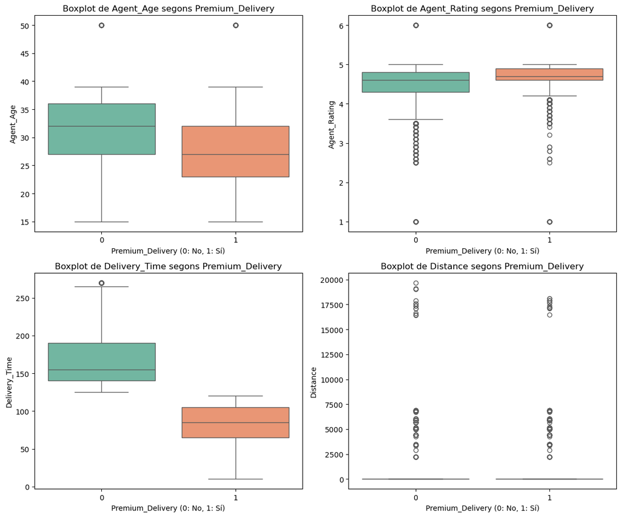

```python
numerical_vars = data.select_dtypes(include=['float64', 'int64'])

plt.figure(figsize=(12, 10))
for i, var in enumerate(numerical_vars, 1):
    plt.subplot(2, 2, i)
    sns.boxplot(x='Premium_Delivery', y=var, data=data, palette='Set2')
    plt.title(f"Boxplot de {var} segons Premium_Delivery")
    plt.xlabel("Premium_Delivery (0: No, 1: Sí)")
    plt.ylabel(var)

plt.tight_layout()
plt.show()
```

**Mapa de calor de la matriu de correlació**

Un mapa de calor ajudarà a identificar correlacions significatives entre variables numèriques, que podrien suggerir relacions útils per a l'anàlisi i modelització.

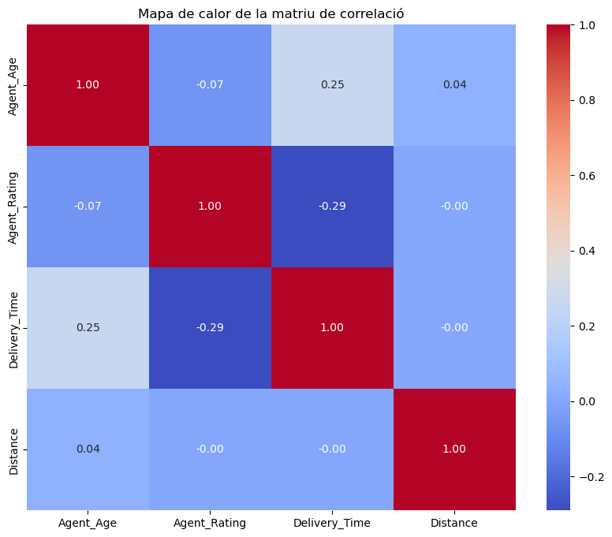

```python
#matriu de correlació
correlation_matrix = numerical_vars.corr()

# heatmap
plt.figure(figsize=(10, 8))
sns.heatmap(correlation_matrix, annot=True, fmt=".2f", cmap="coolwarm", cbar=True)
plt.title("Mapa de calor de la matriu de correlació")
plt.show()
```

El mapa de calor de la matriu de correlació mostra les relacions entre les variables numèriques del conjunt de dades.

## 2.3. Preprocessament de Dades (1.25 punts)

El preprocessament de dades en ciència de dades és un pas crucial que implica la preparació i transformació de dades brutes en un format adequat per a la seva posterior anàlisi i modelatge. Aquest procés inclou diverses tasques essencials:

1. **Neteja de Dades**: S’eliminen o corregeixen dades errònies, incompletes, inexactes o irrellevants. Això pot incloure tractar amb valors faltants, corregir errors d’entrada i gestionar outliers.
2. **Normalització i Escalat**: Les dades es transformen perquè estiguin en una escala comuna, sense distorsionar diferències en els rangs de valors ni perdre informació. Per exemple, escalat min-max o estandardització.
3. **Codificació de Variables Categòriques**: Les variables categòriques (com gènere o país) es converteixen en formats numèrics perquè puguin ser processades per algorismes d’aprenentatge automàtic, utilitzant tècniques com codificació one-hot o codificació d’etiquetes.
4. **Divisió de Dades**: Les dades es divideixen en conjunts d’entrenament, validació i prova, permetent entrenar models, ajustar hiperparàmetres i avaluar el rendiment del model de manera efectiva.
5. **Gestió de Dades Desbalancejades**: En casos de conjunts de dades desbalancejats, s’apliquen tècniques com sobremostreig o submostreig per assegurar que el model no estigui esbiaixat cap a la classe més freqüent.
6. **Enginyeria de Característiques**: Es creen noves variables (característiques) a partir de les dades existents per millorar la capacitat del model per aprendre patrons i fer prediccions.

El preprocessament és essencial per millorar la qualitat de les dades i fer-les més adequades i efectives per a l’anàlisi i el modelatge en projectes de ciència de dades.

**Implementació:** elimina els atributs categòrics del conjunt de dades i, en el seu lloc, introdueix la transformació d’aquests atributs a tantes variables binàries com categories tinguin. És important que les noves columnes generades siguin de tipus enter. Recorda que la codificació one-hot converteix les etiquetes categòriques en vectors binaris. En aquests vectors, el valor de 1 s’assigna a la posició corresponent a la classe i el valor de 0 a totes les altres posicions. Això facilita que els models d’aprenentatge automàtic processin i entenguin les etiquetes categòriques.

Suggeriment: utilitzeu la funció "get_dummies" de "pandas".

**Solució:**

```python
categorical_vars = data.select_dtypes(include=['object']).columns
data_encoded = pd.get_dummies(data, columns=categorical_vars, dtype=int)

print("Mostra del dataset codificat amb One-Hot Encoding:")

data_encoded.head()
```

```
Mostra del dataset codificat amb One-Hot Encoding:
```

|  | Agent_Age | Agent_Rating | Delivery_Time | Premium_Delivery | Distance | Weather_Cloudy | Weather_Fog | Weather_Sandstorms | Weather_Stormy | Weather_Sunny | ... | Category_Home | Category_Jewelry | Category_Kitchen | Category_Outdoors | Category_Pet Supplies | Category_Shoes | Category_Skincare | Category_Snacks | Category_Sports | Category_Toys |
| --- | --- | --- | --- | --- | --- | --- | --- | --- | --- | --- | --- | --- | --- | --- | --- | --- | --- | --- | --- | --- | --- |
| 0 | 37 | 4.9 | 120 | 1 | 3.025149 | 0 | 0 | 0 | 0 | 1 | ... | 0 | 0 | 0 | 0 | 0 | 0 | 0 | 0 | 0 | 0 |
| 1 | 34 | 4.5 | 165 | 0 | 20.183530 | 0 | 0 | 0 | 1 | 0 | ... | 0 | 0 | 0 | 0 | 0 | 0 | 0 | 0 | 0 | 0 |
| 2 | 23 | 4.4 | 130 | 0 | 1.552758 | 0 | 0 | 1 | 0 | 0 | ... | 0 | 0 | 0 | 0 | 0 | 0 | 0 | 0 | 1 | 0 |
| 3 | 38 | 4.7 | 105 | 1 | 7.790401 | 0 | 0 | 0 | 0 | 1 | ... | 0 | 0 | 0 | 0 | 0 | 0 | 0 | 0 | 0 | 0 |
| 4 | 32 | 4.6 | 150 | 0 | 6.210138 | 1 | 0 | 0 | 0 | 0 | ... | 0 | 0 | 0 | 0 | 0 | 0 | 0 | 0 | 0 | 1 |

5 rows × 40 columns

```python
encoded_columns = data_encoded.columns
encoded_dtypes = data_encoded.dtypes.unique()
print("\nNoves columnes generades:", encoded_columns)
print("\nTipus de dades en el dataset codificat:", encoded_dtypes)
```

```
Noves columnes generades: Index(['Agent_Age', 'Agent_Rating', 'Delivery_Time', 'Premium_Delivery',
       'Distance', 'Weather_Cloudy', 'Weather_Fog', 'Weather_Sandstorms',
       'Weather_Stormy', 'Weather_Sunny', 'Weather_Windy', 'Traffic_High ',
       'Traffic_Jam ', 'Traffic_Low ', 'Traffic_Medium ', 'Traffic_NaN ',
       'Vehicle_bicycle ', 'Vehicle_motorcycle ', 'Vehicle_scooter ',
       'Vehicle_van', 'Area_Metropolitian ', 'Area_Other', 'Area_Semi-Urban ',
       'Area_Urban ', 'Category_Apparel', 'Category_Books',
       'Category_Clothing', 'Category_Cosmetics', 'Category_Electronics',
       'Category_Grocery', 'Category_Home', 'Category_Jewelry',
       'Category_Kitchen', 'Category_Outdoors', 'Category_Pet Supplies',
       'Category_Shoes', 'Category_Skincare', 'Category_Snacks',
       'Category_Sports', 'Category_Toys'],
      dtype='object')

Tipus de dades en el dataset codificat: [dtype('int64') dtype('float64') dtype('int32')]
```

**Implementació:**

A la primera secció de l’exercici vam observar que la columna `Agent_Rating` tenia un nombre reduït de valors nuls. En aquest exercici hem d’imputar els valors nuls pel valor mínim de la columna i verificar que cap columna addicional té valors nuls.

**Solució:**

```python
missing_values = data_encoded.isnull().sum()
columns_with_missing = missing_values[missing_values > 0]

missing_check_initial = {
    "Cap columna addicional té valors nuls": columns_with_missing.empty,
    "Columnes amb valors nuls restants": columns_with_missing.to_dict()
}
missing_check_initial
```

```
{'Cap columna addicional té valors nuls': False,
 'Columnes amb valors nuls restants': {'Agent_Rating': 54}}
```

```python
# Imputem els valors nuls de "Agent_Rating" amb el valor mínim de la columna

min_agent_rating = data_encoded['Agent_Rating'].min()
data_encoded['Agent_Rating'].fillna(min_agent_rating, inplace=True)

missing_values = data_encoded.isnull().sum()
columns_with_missing = missing_values[missing_values > 0]

missing_check = {
    "Cap columna addicional té valors nuls": columns_with_missing.empty,
    "Columnes amb valors nuls restants": columns_with_missing.to_dict()
}

missing_check
```

```
{'Cap columna addicional té valors nuls': True,
 'Columnes amb valors nuls restants': {}}
```

**Implementació:**

Ara dividirem el conjunt de dades. Per fer-ho, segueix aquests passos:

1. Separa els descriptors de la variable resposta. Assigna els descriptors al conjunt `X` i la variable resposta al conjunt `y`.
2. Elimina del conjunt de descriptors la columna `Delivery_Time`, ja que va ser utilitzada per calcular la nostra variable resposta.
3. Divideix el *dataset* en dos subconjunts: un per a entrenament (*train*) i un altre per a proves (*test*). Assigna el 80% de les dades al conjunt d’entrenament (`X_train`, `y_train`) i el 20% al conjunt de proves (`X_test`, `y_test`). Utilitza la funció `train_test_split` de la biblioteca `model_selection` de `sklearn`. Assegura’t d’utilitzar `random_state = 24` i fes una divisió estratificada per mantenir la mateixa proporció de classes en ambdós conjunts.

**Solució:**

```python
from sklearn.model_selection import train_test_split

X = data_encoded.drop(columns=['Premium_Delivery', 'Delivery_Time'])
y = data_encoded['Premium_Delivery']

# train i test
X_train, X_test, y_train, y_test = train_test_split(
    X, y, test_size=0.2, random_state=24, stratify=y
)

class_distribution = {
    "Train Class Distribution": y_train.value_counts(normalize=True).to_dict(),
    "Test Class Distribution": y_test.value_counts(normalize=True).to_dict()
}

X_train.shape, X_test.shape, class_distribution
```

```
((34991, 38),
 (8748, 38),
 {'Train Class Distribution': {0: 0.5119316395644594, 1: 0.4880683604355406},
  'Test Class Distribution': {0: 0.5120027434842249, 1: 0.487997256515775}})
```

**Implementació:**

1. Normalitza els descriptors utilitzant el `StandardScaler` de `sklearn`. Això estandarditzarà les característiques restant la mitjana i dividint per la desviació estàndard.
2. Mostra les dimensions del conjunt de descriptors original, del conjunt d’entrenament i del conjunt de prova. Això et permetrà veure com s’han dividit les dades.

**Nota:** Ajusta el `StandardScaler` únicament amb els descriptors d’entrenament per evitar la fuga d’informació o 'data leakage'. La fuga d’informació ocorre quan s’utilitza informació del conjunt de prova o validació en el procés d’ajust del model. És a dir, si ajustes el model d’escalat amb tot el conjunt de dades, estaries utilitzant informació del conjunt de prova o validació en l’ajust, fet que podria donar la impressió que el model és més precís del que realment és. Per tant, assegura’t d’ajustar el `StandardScaler` només amb les dades d’entrenament i després aplicar-lo als conjunts d’entrenament i prova.

**Solució:**

```python
scaler = StandardScaler()

X_train_scaled = scaler.fit_transform(X_train)
X_test_scaled = scaler.transform(X_test)

dataset_dimensions = {
    "Original dataset dimensions (X)": X.shape,
    "Training set dimensions (X_train)": X_train.shape,
    "Test set dimensions (X_test)": X_test.shape
}

dataset_dimensions
```

```
{'Original dataset dimensions (X)': (43739, 38),
 'Training set dimensions (X_train)': (34991, 38),
 'Test set dimensions (X_test)': (8748, 38)}
```

**Implementació:**

Converteix els conjunts de dades d’entrenament i prova en tensors utilitzant el mètode `tensor` de la biblioteca `PyTorch`.

**Solució:**

```python
import torch

# train i test a tensors
X_train_tensor = torch.tensor(X_train_scaled, dtype=torch.float32)
X_test_tensor = torch.tensor(X_test_scaled, dtype=torch.float32)
y_train_tensor = torch.tensor(y_train.values, dtype=torch.float32)
y_test_tensor = torch.tensor(y_test.values, dtype=torch.float32)

tensor_shapes = {
    "X_train_tensor shape": X_train_tensor.shape,
    "X_test_tensor shape": X_test_tensor.shape,
    "y_train_tensor shape": y_train_tensor.shape,
    "y_test_tensor shape": y_test_tensor.shape
}

tensor_shapes
```

```
{'X_train_tensor shape': torch.Size([34991, 38]),
 'X_test_tensor shape': torch.Size([8748, 38]),
 'y_train_tensor shape': torch.Size([34991]),
 'y_test_tensor shape': torch.Size([8748])}
```

## 2.4. Modelització (2 punts)

El MLP (Perceptró Multicapa) és, sens dubte, una eina poderosa en el camp de l’aprenentatge automàtic i la intel·ligència artificial. Pot manejar tasques de classificació i regressió, fet que el fa versàtil per a una varietat de problemes. La seva capacitat per modelar relacions no lineals complexes el converteix en una elecció popular quan les dades no segueixen patrons lineals simples.

Aquí hi ha alguns punts clau sobre el MLP:

- **Capes i Neurones**: El MLP consta de múltiples capes de neurones, que inclouen una capa d’entrada, una o més capes ocultes i una capa de sortida. Cada neurona d’una capa està connectada a totes les neurones de la capa següent.
- **Funcions d’Activació**: Per introduir no linealitat en el model, s’utilitzen funcions d’activació a les neurones, com la funció sigmoide, ReLU (Rectified Linear Unit) o tangent hiperbòlica. Aquestes funcions permeten al MLP capturar patrons complexos en les dades.
- **Aprenentatge Supervisat**: L’entrenament del MLP implica ajustar els pesos de les connexions entre neurones per minimitzar la diferència entre les sortides produïdes per la xarxa i les sortides desitjades. Això es fa utilitzant algorismes d’aprenentatge supervisat, com el descens del gradient.
- **Ajust d’Hiperparàmetres**: Igual que altres models d’aprenentatge automàtic, el MLP té hiperparàmetres importants, com el nombre de capes ocultes, el nombre de neurones a cada capa, la funció d’activació i la taxa d’aprenentatge. Sovint, és necessari ajustar aquests hiperparàmetres per obtenir un bon rendiment en una tasca específica.
- **Generalització**: Un dels desafiaments en l’entrenament de MLP és evitar el sobreajustament (overfitting), on el model s’adapta massa a les dades d’entrenament i no generalitza bé a dades noves. La regularització i la validació creuada són tècniques comunes per abordar aquest problema.

En aquest context, el MLP pot ser una excel·lent opció per modelar patrons complexos que indiquin quan una entrega serà premium. No obstant això, és important ajustar i avaluar acuradament el model per garantir que funcioni de manera efectiva en aquesta tasca crítica.

Crear i entrenar un MLP amb diverses capes ocultes amb funció d’activació ReLU és una excel·lent elecció. La funció d’activació ReLU (Rectified Linear Unit) s’utilitza comunament a capes ocultes de xarxes neuronals a causa de la seva capacitat per introduir no linealitat al model, permetent-li aprendre patrons complexos a les dades.

D’altra banda, l’enfocament d’apilar capes lineals utilitzant la classe `Linear` de PyTorch és una forma eficaç i senzilla de construir models de xarxes neuronals.

```python
def train_model(model, X_train, y_train, X_val, y_val, n_epochs, batch_size):
    batch_start = torch.arange(0, len(X_train), batch_size)
    optimizer = optim.Adam(model.parameters(), lr=0.0001)
    loss_fn = nn.BCELoss()

    best_acc = - np.inf
    best_weights = None

    train_loss_hist = []
    train_acc_hist = []
    val_loss_hist = []
    val_acc_hist = []

    for epoch in range(n_epochs):
        epoch_loss = []
        epoch_acc = []
        model.train()

        with tqdm.tqdm(batch_start, unit="batch", mininterval=0, disable=True) as bar:
            bar.set_description(f"Epoch {epoch}")
            for start in bar:

                # take a batch
                X_batch = X_train[start:start+batch_size]
                y_batch = y_train[start:start+batch_size]

                # forward pass
                y_pred = model(X_batch)
                loss = loss_fn(y_pred, y_batch)

                # backward pass
                optimizer.zero_grad()
                loss.backward()

                # update weights
                optimizer.step()

                # compute and store metrics
                acc = (y_pred.round() == y_batch).float().mean()
                epoch_loss.append(float(loss))
                epoch_acc.append(float(acc))
                bar.set_postfix(
                    loss=float(loss),
                    acc=float(acc)
                )

        # Evaluating the model at the end of each epoch
        model.eval()
        y_pred = model(X_val)
        ce = float(loss_fn(y_pred, y_val))
        acc = float((y_pred.round() == y_val).float().mean())

        train_loss_hist.append(np.mean(epoch_loss))
        train_acc_hist.append(np.mean(epoch_acc))
        val_loss_hist.append(ce)
        val_acc_hist.append(acc)

        if acc > best_acc:
            best_acc = acc
            best_weights = copy.deepcopy(model.state_dict())
        # print(f"Epoch {epoch} validation: Cross-entropy={ce:.2f}, Accuracy={acc*100:.1f}%")

    model.load_state_dict(best_weights)
    return best_acc, train_loss_hist, val_loss_hist, train_acc_hist, val_acc_hist
```

**Implementació:**

La modelització del MLP la realitzarem amb la biblioteca `PyTorch`. Per fer-ho:

1. Comença creant el model `BinaryServiceLevel`, per al qual és necessari crear una classe que hereti de `nn.Module`.
2. Al constructor (`__init__`), declara les següents capes:
   - Una capa lineal `nn.Linear` d’entrada amb una mida de sortida de 19, i una funció d’activació ReLU `nn.ReLU`.
   - Una capa lineal `nn.Linear` amb una mida de sortida de 19, i una funció d’activació ReLU `nn.ReLU`.
   - Una capa lineal `nn.Linear` de sortida amb una funció d’activació Sigmoid `nn.Sigmoid`.
3. Després, al mètode `forward` enllaça les diferents capes i les seves respectives funcions d’activació en l’ordre definit en el punt anterior.
4. No oblidis mostrar el nombre de paràmetres utilitzant el mètode `.parameters()` del model.

```python
class BinaryServiceLevelBase(nn.Module):
    def __init__(self, input_size):
        super().__init__()
        self.fc1 = nn.Linear(input_size, 19)
        self.relu1 = nn.ReLU()
        self.fc2 = nn.Linear(19, 19)
        self.relu2 = nn.ReLU()
        self.fc3 = nn.Linear(19, 1)
        self.sigmoid = nn.Sigmoid()

    def forward(self, x):
        x = self.fc1(x)
        x = self.relu1(x)
        x = self.fc2(x)
        x = self.relu2(x)
        x = self.fc3(x)
        x = self.sigmoid(x)
        return x
```

**Solució:**

```python
input_size = X_train_tensor.shape[1]
model = BinaryServiceLevelBase(input_size)

num_params = sum(p.numel() for p in model.parameters())
print(f"Nombre total de paràmetres del model: {num_params}")
```

```
Nombre total de paràmetres del model: 1141
```

**Implementació:**

1. Ara és el moment d’entrenar i validar el model aplicant validació creuada utilitzant `StratifiedKFold` sobre el conjunt d’entrenament, amb un valor de k = 5 i `shuffle = True`.
2. En cada divisió (split), el model s’ha d’entrenar utilitzant la funció `train_model`. Assegura’t d’entrenar amb les dades d’entrenament i validació de cada divisió, establint el nombre d’èpoques en 15 i la mida del lot en 32.
3. En cada iteració s’han de calcular les següents mètriques:
   - Calcula l’exactitud (*accuracy*) per mesurar la precisió de les prediccions.
   - Calcula el valor F1, que és una mesura que combina precisió i sensibilitat.
   - Calcula l’àrea sota la corba ROC (AUC-ROC) per avaluar el rendiment del model en la classificació binària.
4. Finalment, s’ha de mostrar la mitjana de cadascuna de les mètriques calculades en el punt anterior.

**Solució:**

```python
from sklearn.metrics import accuracy_score, f1_score, roc_auc_score

# Paràmetres d'entrenament
n_epochs = 15
batch_size = 32
learning_rate = 0.0001

# StratifiedKFold
skf = StratifiedKFold(n_splits=5, shuffle=True, random_state=24)

accuracy_list = []
f1_list = []
roc_auc_list = []

# Entrenament i validació
for train_idx, val_idx in skf.split(X_train_tensor, y_train_tensor):
    X_train_fold, X_val_fold = X_train_tensor[train_idx], X_train_tensor[val_idx]
    y_train_fold, y_val_fold = y_train_tensor[train_idx], y_train_tensor[val_idx]

    input_size = X_train_fold.shape[1]
    model = BinaryServiceLevelBase(input_size)
    optimizer = optim.Adam(model.parameters(), lr=learning_rate)
    loss_fn = nn.BCELoss()

    # Entrenar el model
    for epoch in range(n_epochs):
        model.train()
        for start in range(0, len(X_train_fold), batch_size):
            X_batch = X_train_fold[start:start+batch_size]
            y_batch = y_train_fold[start:start+batch_size].view(-1, 1)

            y_pred = model(X_batch)
            loss = loss_fn(y_pred, y_batch)

            optimizer.zero_grad()
            loss.backward()
            optimizer.step()

    model.eval()
    with torch.no_grad():
        y_val_pred = model(X_val_fold).numpy()
        y_val_pred_class = (y_val_pred > 0.5).astype(int)

    acc = accuracy_score(y_val_fold.numpy(), y_val_pred_class)
    f1 = f1_score(y_val_fold.numpy(), y_val_pred_class)
    roc_auc = roc_auc_score(y_val_fold.numpy(), y_val_pred)

    accuracy_list.append(acc)
    f1_list.append(f1)
    roc_auc_list.append(roc_auc)

mean_accuracy = sum(accuracy_list) / len(accuracy_list)
mean_f1 = sum(f1_list) / len(f1_list)
mean_roc_auc = sum(roc_auc_list) / len(roc_auc_list)

results = {
    "Mitjana Accuracy": mean_accuracy,
    "Mitjana F1": mean_f1,
    "Mitjana AUC-ROC": mean_roc_auc
}

results
```

```
{'Mitjana Accuracy': 0.7891743690490058,
 'Mitjana F1': 0.7855357085382734,
 'Mitjana AUC-ROC': 0.8850802411344466}
```

**Anàlisi:**

1. Realitza una anàlisi dels resultats i decideix si consideres que aquest model és acceptable.
2. Avalua quina de les mesures de rendiment utilitzades és la més apropiada.
3. Examina la distribució de les classes i planteja una estratègia, si és necessari, per assegurar la fiabilitat de l’estudi realitzat.

**Resposta:**

La mesura més apropiada per aquest problema és l’AUC-ROC, perquè reflecteix la capacitat del model per distingir entre les classes, independentment del llindar utilitzat per decidir la classificació.

El F1 Score també és important, ja que proporciona una perspectiva sobre com el model maneja la precisió i la sensibilitat, que són crucials si hi ha desbalanceig entre les classes.

```python
class_distribution = y_train_tensor.numpy()
unique, counts = np.unique(class_distribution, return_counts=True)

class_distribution_summary = dict(zip(unique, counts))

total_samples = sum(counts)
class_proportions = {k: v / total_samples for k, v in class_distribution_summary.items()}

class_distribution_summary, class_proportions
```

```
({0.0: 17913, 1.0: 17078}, {0.0: 0.5119316395644594, 1.0: 0.4880683604355406})
```

- Classe 0 (No Premium): 17,913 mostres (51.19%)
- Classe 1 (Premium): 17,078 mostres (48.81%)

Les classes estan força equilibrades, amb una diferència molt petita entre les proporcions de les dues classes. Això implica que no cal aplicar tècniques de gestió de desbalanceig ni noves estratègies.

**Implementació:**

Ara és el moment d’analitzar la fase d’entrenament. Per fer-ho:

1. Divideix el conjunt d’entrenament en dos subconjunts: un per a entrenament (train) i un altre per a validació (val), assignant el 80% de les dades al conjunt d’entrenament.
2. Entrena el model amb la funció `model_train`, guardant tots els paràmetres que retorna.
3. Crea gràfics que mostrin la pèrdua (`loss`) tant en l’entrenament com en la validació al llarg de les èpoques.
4. Finalment, genera gràfics que representin l’exactitud (`accuracy`) en l’entrenament i la validació al llarg de les èpoques.

**Solució:**

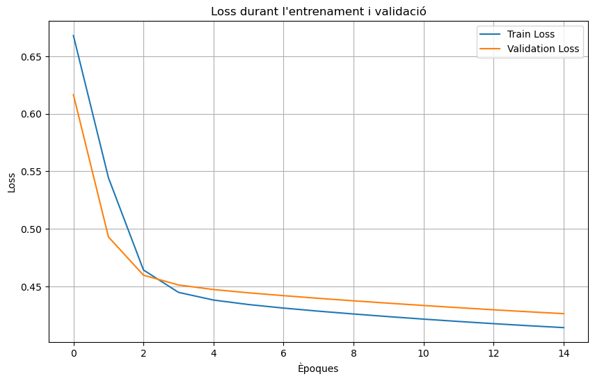

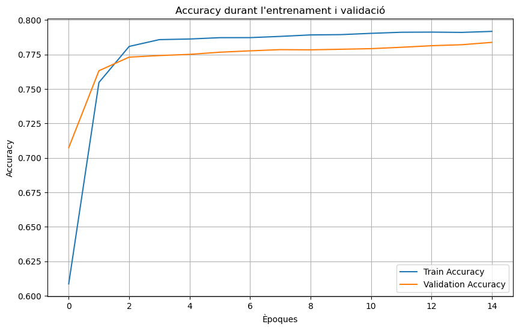

```python
X_train_split, X_val_split, y_train_split, y_val_split = train_test_split(
    X_train_tensor, y_train_tensor, test_size=0.2, random_state=24, stratify=y_train_tensor
)

model = BinaryServiceLevelBase(input_size)
best_acc, train_loss_hist, val_loss_hist, train_acc_hist, val_acc_hist = train_model(
    model, X_train_split, y_train_split.view(-1, 1), X_val_split, y_val_split.view(-1, 1), n_epochs=15, batch_size=32
)

plt.figure(figsize=(10, 6))
plt.plot(train_loss_hist, label="Train Loss")
plt.plot(val_loss_hist, label="Validation Loss")
plt.title("Loss durant l'entrenament i validació")
plt.xlabel("Èpoques")
plt.ylabel("Loss")
plt.legend()
plt.grid()
plt.show()

plt.figure(figsize=(10, 6))
plt.plot(train_acc_hist, label="Train Accuracy")
plt.plot(val_acc_hist, label="Validation Accuracy")
plt.title("Accuracy durant l'entrenament i validació")
plt.xlabel("Èpoques")
plt.ylabel("Accuracy")
plt.legend()
plt.grid()
plt.show()
```

**Anàlisi:**

Quines conclusions pots obtenir de les gràfiques tant de la pèrdua (`loss`) com de l’exactitud (`accuracy`) en l’entrenament i la validació al llarg de les èpoques?

**Resposta:**

Les gràfiques de pèrdua (loss) mostren una tendència decreixent tant per a l'entrenament com per a la validació a mesura que avancen les èpoques. Això indica que el model està aprenent patrons de les dades i millorant el seu rendiment. A més, la pèrdua de validació segueix una trajectòria molt similar a la de l'entrenament, sense grans divergències, la qual cosa suggereix que no hi ha signes de sobreajustament (overfitting), ja que la pèrdua de validació no augmenta cap al final.

Pel que fa a les gràfiques d'exactitud (accuracy), s'observa una millora contínua en les primeres èpoques, seguida d'una estabilització. Tant l'exactitud de l'entrenament com la de la validació mostren trajectòries similars, amb la validació lleugerament inferior a l'entrenament, un comportament esperable i acceptable. Aquestes observacions reflecteixen que el model està convergint cap a un rendiment consistent sense sobreajustar-se a les dades d'entrenament.

Podem dir doncs, que aquestes gràfiques indiquen que el model està ben ajustat a les dades. No es detecten problemes de subajustament o sobreajustament, i el rendiment és fiable.

**Implementació:**

És hora d’avaluar el rendiment del model en el conjunt de prova. Per fer-ho:

1. Realitza la predicció sobre el conjunt de prova.
2. Calcula les mètriques dels apartats anteriors: exactitud (accuracy), F1 score i corba ROC.

**Solució:**

```python
model.eval()
with torch.no_grad():
    y_test_pred = model(X_test_tensor).numpy()
    y_test_pred_class = (y_test_pred > 0.5).astype(int)

test_accuracy = accuracy_score(y_test_tensor.numpy(), y_test_pred_class)
test_f1 = f1_score(y_test_tensor.numpy(), y_test_pred_class)
test_auc_roc = roc_auc_score(y_test_tensor.numpy(), y_test_pred)

test_results = {
    "Accuracy (Conjunt de Prova)": test_accuracy,
    "F1 Score (Conjunt de Prova)": test_f1,
    "AUC-ROC (Conjunt de Prova)": test_auc_roc
}

test_results
```

```
{'Accuracy (Conjunt de Prova)': 0.7861225422953818,
 'F1 Score (Conjunt de Prova)': 0.7827702310460931,
 'AUC-ROC (Conjunt de Prova)': 0.8808659457677904}
```

**Implementació:**

Per analitzar el model entrenat, ens basarem en els [Shapley values](https://en.wikipedia.org/wiki/Shapley_value), que introdueixen l’explicació de models d’aprenentatge automàtic. L’objectiu és explicar la predicció d’un model calculant la contribució de cada característica a la predicció. La descripció tècnica del concepte de SHAP és el càlcul dels valors de Shapley a partir de la teoria de jocs. En poques paraules, els valors de Shapley són un mètode per mostrar l’impacte relatiu de cada característica (o variable) que estem mesurant en el resultat final del model d’aprenentatge automàtic, comparant l’efecte relatiu de les entrades amb la mitjana.

Per calcular els *shap values*:

1. Selecciona una mostra de 10000 registres del conjunt d’entrenament.
2. Inicialitza l’'explainer' `shap.DeepExplainer` amb el model entrenat i la mostra anterior.
3. Selecciona una mostra de 400 registres del conjunt d’entrenament.
4. Calcula els *shap values* utilitzant la mostra anterior.
5. Defineix i mostra un DataFrame amb tres columnes:
   - Mitjana aritmètica del valor absolut dels valors.
   - Desviació típica del valor absolut dels valors.
   - Nom de l’atribut descriptiu.
6. Mostra la representació gràfica dels valors utilitzant la biblioteca SHAP.

**Solució:**

```
Resum dels SHAP values:
                  Feature  Mean Absolute Shap Value  Standard Deviation
0               Agent_Age                  0.130839            0.085641
11           Traffic_Low                   0.111617            0.055747
10           Traffic_Jam                   0.084862            0.047104
1            Agent_Rating                  0.081403            0.087626
27       Category_Grocery                  0.055150            0.122215
7           Weather_Sunny                  0.052567            0.060161
3          Weather_Cloudy                  0.047814            0.046941
4             Weather_Fog                  0.044649            0.044519
21            Area_Urban                   0.030289            0.025340
15    Vehicle_motorcycle                   0.029958            0.016795
6          Weather_Stormy                  0.023474            0.023393
8           Weather_Windy                  0.022675            0.024577
5      Weather_Sandstorms                  0.020748            0.021789
```

[output cut: 25 more lines]

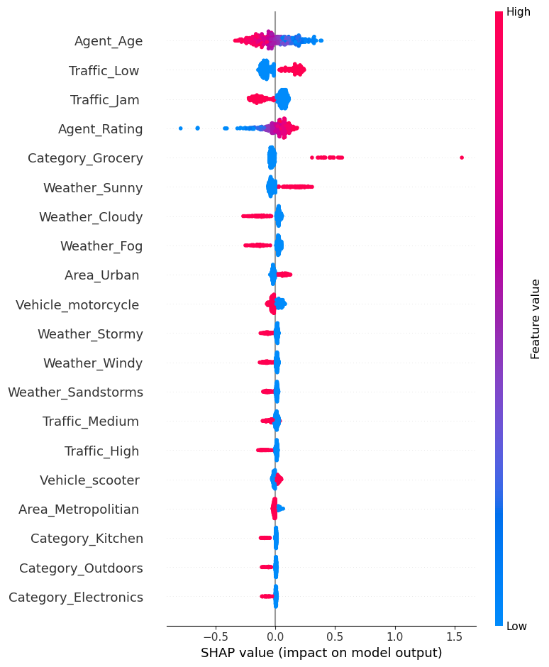

```python
# 10000 registres del conjunt d’entrenament
sample_size = min(10000, len(X_train_tensor))
train_sample = X_train_tensor[:sample_size]

# Inicialitzar el SHAP
explainer = shap.DeepExplainer(model, train_sample)

#400 registres del conjunt d’entrenament
explain_sample_size = min(400, len(X_train_tensor))
explain_sample = X_train_tensor[:explain_sample_size]

# SHAP values
shap_values = explainer.shap_values(explain_sample)
shap_features = X_train.columns

# # Reduir dimensions de (400, 38, 1) a (400, 38)
shap_values_reduced = np.squeeze(shap_values)

shap_mean = np.mean(np.abs(shap_values_reduced), axis=0)
shap_std = np.std(np.abs(shap_values_reduced), axis=0)

shap_summary = pd.DataFrame({
    "Feature": shap_features,
    "Mean Absolute Shap Value": shap_mean,
    "Standard Deviation": shap_std
}).sort_values(by="Mean Absolute Shap Value", ascending=False)
print("Resum dels SHAP values:")
print(shap_summary)

shap.summary_plot(shap_values_reduced, explain_sample.numpy(), feature_names=shap_features)
```

**Anàlisi:**

Relaciona la interpretació dels *shap values* amb l’anàlisi exploratori de les dades realitzat a l’exercici 2.2.

**Resposta:**

La interpretació dels SHAP values ens permet identificar quines característiques tenen el major impacte en les prediccions del model i relacionar-les amb els patrons observats durant l'anàlisi exploratori de dades.

Característiques destacades amb alt impacte:

- Agent_Age és la característica amb el major impacte mitjà absolut segons els SHAP values. Això està alineat amb l'anàlisi exploratori, on l'edat dels agents podia suggerir una relació amb el tipus d'entrega (Premium o No Premium).
- Traffic_Low i Traffic_Jam també tenen un impacte significatiu. Durant l'EDA, es va observar que la classificació del trànsit pot influir en el temps de lliurament i, per tant, en la probabilitat que l'entrega sigui premium.
- Agent_Rating mostra un fort impacte en el model, consistent amb l'observació que els agents amb puntuacions més altes tenien més probabilitat d'associar-se amb entregues premium.

Variables relacionades amb el clima:

- Weather_Sunny, Weather_Cloudy, i Weather_Fog tenen un impacte moderat. Això és coherent amb l'EDA, ja que les condicions meteorològiques poden influir en la logística de les entregues.

Variables categòriques:

- Categories com Category_Grocery i Vehicle_motorcycle tenen un impacte rellevant. Durant l'EDA, es va observar que algunes categories específiques podrien estar associades a entregues més ràpides o prioritàries, la qual cosa és coherent amb els resultats de SHAP.

Característiques amb menys impacte:

- Variables com Traffic_NaN, Distance, i algunes categories (com Category_Toys o Category_Pet Supplies) tenen un impacte negligible, la qual cosa suggereix que no contribueixen significativament a la predicció del model. Això també pot ser consistent amb l'EDA, on aquestes variables no mostraven patrons forts o rellevants.

**Anàlisi:**

Imagina que calculem els *shap values* per a cada divisió (split) en l’exercici en què vam entrenar el model utilitzant validació creuada.

- Els anàlisis dels diferents models haurien de ser similars? Per què o per què no?
- Què indicaria si l’anàlisi de cada model varia molt d’un a l’altre?
- Quins usos addicionals podem donar als *shap values*?

**Resposta:**

### 1. Els anàlisis dels models haurien de ser similars?

Sí, els resultats haurien de ser similars, ja que les divisions de la validació creuada estan dissenyades per reflectir la mateixa distribució general de les dades. Això és esperable si:

- Les dades estan ben estratificades, assegurant que cada divisió representa adequadament el conjunt global.
- El model aprèn patrons consistents i robustos que es mantenen estables entre els diferents splits.

### 2. Què indica si l’anàlisi varia molt?

Si els valors SHAP varien molt entre divisions, això podria indicar problemes en les dades o en el model. Això pot ser causat per:

- Soroll o biaixos inherents a les dades que dificulten l’aprenentatge de patrons consistents.
- Un model inestable que és sensible a petites variacions en el conjunt d’entrenament, la qual cosa pot reflectir un sobreajustament.
- Divisions de dades que no representen adequadament la distribució original, la qual cosa podria alterar el comportament del model entre splits.

### 3. Usos addicionals dels SHAP values

Els SHAP values són una eina poderosa que es pot utilitzar en diversos àmbits per entendre i millorar el comportament dels models. Alguns dels seus usos més destacats són:

- **Explicabilitat**: Permeten entendre la contribució de cada característica a les prediccions del model, fent-lo més transparent i interpretatiu.
- **Selecció de variables**: Identifiquen variables amb poca rellevància, ajudant a reduir dimensionalitat i a simplificar el model sense perdre rendiment.
- **Detecció d’anomalies**: Poden revelar patrons inusuals o outliers en el conjunt de dades.
- **Ajust del model**: Ajuden a identificar inconsistències i a refinar hiperparàmetres per millorar el rendiment.
- **Anàlisi de biaixos**: Permeten detectar impactes desproporcionats d’algunes característiques, ajudant a garantir que el model sigui més just i equilibrat.

Amb els SHAP values, podem entendre millor les decisions del model, seleccionar les variables més importants i detectar patrons problemàtics o útils que millorin la fiabilitat i robustesa del sistema.